# Analysis Note: Object Orientation across languages

Sau-Chin Chen

2021-07-29

## Result marks

[output not shown]

## update log:

20210714: All the preregistered analysis were finished. 20210715: The source data are available at public [OSF](https://osf.io/2zxrw/). 20210720-21: Revised PP dataset settings for the mixed-effect model; Add the interaction plots for SP and PP analysis. 20210725: Updated mixed-effect models for each part. Decided the best fitted model and notified the convergence problem. 20210726: tested `allFit` on “source_cor.lmer”. Plan for the other unconvergent models is requried. 20210728-29: confirmed the best fitted model in each mixed-effect model chunk. The results appendix will include the comparisons among the models.

All available raw data are from three files:

- `[all_rawdata_SP_V.csv](https://osf.io/msd97/)` the sentence-picture verification responses.
- `[all_rawdata_SP_M.csv](https://osf.io/4duce/)` the responses of memory trials.
- `[all_rawdata_PP.csv](https://osf.io/qfrhu/)` the picture-picture verification responses.

Meta data in the analysis stream:

- `[Lab_info.csv](https://osf.io/s2fg6/)` Registered teams information
- `[lab_fin.csv](https://osf.io/8jse6/)` Teams finished data collection
- `[insite_meta.csv](https://osf.io/yjxbw/)` meta data of in-site rawdata
- `[jatos_meta.csv](https://osf.io/x5zmw/)` meta data of osweb rawdata

## Import raw data and lab information

```r
# Load lab information
lab_info <- ##dirname(getwd()) %>%
  dir(path = "..",full.names = TRUE, recursive = TRUE, include.dirs = TRUE, pattern = "Lab_info.csv")  %>%
  read_csv()

lab_fin <- ##dirname(getwd()) %>%
  dir(path = "..",full.names = TRUE, recursive = TRUE, include.dirs = TRUE, pattern = "lab_fin.csv")  %>%
  read_csv()

# Load meta data of in site data: age, female numbers

insite_meta <- dir(path = "..",full.names = TRUE, recursive = TRUE, include.dirs = TRUE, pattern = "insite_meta.csv") %>%
  read_csv()

# Load and summary meta data of online data: age, female numbers, language proficiency
osweb_meta <- dir(path = "..",full.names = TRUE, recursive = TRUE, include.dirs = TRUE, pattern = "jatos_meta.csv") %>%
  read_csv() %>%
  mutate(gender = ifelse(gender==1,"FEMALE",ifelse(gender==2,"MALE","OTHER"))) %>%
  mutate(birth_year = as.numeric(birth_year)) %>%
  mutate(year = ifelse(birth_year > 21 & !is.na(birth_year), 1900 + birth_year, 2000 + birth_year)) %>%
  mutate(age = ifelse(!is.na(year),2021-year,NA)) %>%
  group_by(Batch) %>%
  summarise(N = n(), Female_N = sum(gender=="FEMALE",na.rm = TRUE), Age = mean(age, na.rm=TRUE), Proficiency = mean(lang_prof))
```

In the site studies, we collected the participants’ gender and age on a splited Qualtrics form. Total 2340 participants (1104 females; averagely 21.46 years old) completed the study in each site.

| PSA_ID | N | Female_N | Age |
| --- | --- | --- | --- |
| AUT_002 | 102 | 77 | 20.86275 |
| CAN_020 | 93 | 52 | 20.15054 |
| CHN_005 | 51 | 29 | 18.50980 |
| CHN_019 | 31 | 13 | 24.87097 |
| COL_001 | 68 | 39 | 21.38235 |
| ECU_001 | 63 | 31 | 21.84127 |
| GBR_005 | 52 | 39 | 20.00000 |
| GBR_006 | 50 | 37 | 20.14000 |
| GBR_014 | 51 | 42 | 18.64706 |
| GBR_043 | 29 | 15 | 25.82759 |

[output cut: 23 more lines]

Considering the online circumstance, we collected the participants’ gender and age at the end of OSWeb script. Before the study we also showed the verbal instruction to confirm the participants’ langauge proficiency. Total 1403 participants (926 females; averagely 23.75 years old) completed the study in each site.

| Batch | N | Female_N | Age | Proficiency |
| --- | --- | --- | --- | --- |
| ARE_001 | 52 | 0 | NaN | 58.92308 |
| ARE_002 | 54 | 42 | 26.93478 | 79.09259 |
| AUS_091 | 160 | 127 | 26.36184 | 86.02500 |
| AUT_005 | 108 | 80 | 22.36893 | 88.04630 |
| BRA_003 | 50 | 36 | 30.80000 | 92.08000 |
| DEU_020 | 26 | 18 | 24.00000 | 87.23077 |
| NGA_001 | 52 | 24 | 24.01961 | 90.48077 |
| NOR_002 | 21 | 12 | 30.09524 | 87.38095 |
| NZL_005 | 320 | 244 | 23.23510 | 90.71875 |
| POR_001 | 55 | 26 | 31.01887 | 86.80000 |

[output cut: 10 more lines]

## Avalability Summary: in site data

Among the data in sites, 2014 participants finished sentence-picture verification task and passed the preregistered exclusion criterion (accuracy percentile > 70%); 2007 participants finished picture-picture verification task. Some PP data files were successfully imported after I decreased the criterion of file size. 7 participants’ data files were lost because the experimenters did not upload the files or submitted the wrong files.

## Avalability Summary: osweb data

Through jatos server, 1337 participants finished sentence-picture verification task and passed the preregistered exclusion criterion (accuracy percentile > 70%); 1337 participants finished picture-picture verification task. We excluded 1 participant from `USA_033` because this participant did not complete the picture-picture verification.

# Avalability Summary: all data

| Language | Lab ID | from site SP | from site PP | from osweb SP | from osweb PP |
| --- | --- | --- | --- | --- | --- |
| Arabic | ARE_001 |  |  | 16 | 16 |
| Arabic | ARE_002 |  |  | 52 | 52 |
| Brazilian Portuguese | BRA_003 |  |  | 49 | 49 |
| English | AUS_091 |  |  | 159 | 159 |
| English | NGA_001 |  |  | 48 | 48 |
| English | NZL_005 |  |  | 311 | 311 |
| English | PSA_002 |  |  | 64 | 64 |
| English | TWN_002E |  |  | 12 | 12 |
| English | USA_011 |  |  | 60 | 60 |
| English | USA_020 | 23 | 23 | 25 | 25 |
| English | USA_030 |  |  | 26 | 26 |
| English | USA_033 | 31 | 31 | 45 | 45 |
| German | AUT_005 |  |  | 108 | 108 |
| German | DEU_020 |  |  | 26 | 26 |
| Norwegian | NOR_002 |  |  | 21 | 21 |
| Portuguese | POR_001 | 5 | 5 | 54 | 54 |
| Serbian | SRB_002 |  |  | 81 | 81 |
| Serbian | SRB_002B |  |  | 47 | 47 |
| Traditional Chinese | TWN_002 | 33 | 33 | 57 | 57 |
| Turkish | TUR_023 |  |  | 76 | 76 |
| English | CAN_020 | 97 | 97 |  |  |
| English | GBR_005 | 52 | 52 |  |  |
| English | GBR_006 | 25 | 25 |  |  |
| English | GBR_014 | 50 | 50 |  |  |
| English | GBR_043 | 25 | 25 |  |  |
| English | MYS_003 | 47 | 47 |  |  |
| English | MYS_004 | 100 | 100 |  |  |
| English | PSA_001 | 41 | 41 |  |  |
| English | TUR_007E | 8 | 8 |  |  |
| English | USA_032 | 50 | 50 |  |  |
| English | USA_065 | 32 | 32 |  |  |
| English | USA_173 | 32 | 31 |  |  |
| German | AUT_002 | 99 | 99 |  |  |
| Greek | GRC_002 | 98 | 98 |  |  |
| Hebrew | ISR_001 | 146 | 145 |  |  |
| Hindi | IND_003 | 79 | 78 |  |  |
| Magyar | HUN_001 | 129 | 129 |  |  |
| Norwegian | NOR_003 | 51 | 51 |  |  |
| Norwegian | NOR_004 | 72 | 70 |  |  |
| Polish | POL_001 | 50 | 50 |  |  |
| Simple Chinese | CHN_005 | 50 | 50 |  |  |
| Simple Chinese | CHN_019 | 31 | 30 |  |  |
| Slovak | SVK_001 | 91 | 91 |  |  |
| Slovak | SVK_002 | 47 | 47 |  |  |
| Spanish | COL_001 | 69 | 69 |  |  |
| Spanish | ECU_001 | 58 | 58 |  |  |
| Thai | THA_001 | 50 | 50 |  |  |
| Traditional Chinese | TWN_001 | 60 | 60 |  |  |
| Turkish | TUR_007 | 84 | 84 |  |  |
| Turkish | TUR_025 | 99 | 98 |  |  |

According to our preregistered plan, each laboratory has to collect at least 50 participants. Some laboratories did not reach the minimal criterion because of the following reasons: (1)their works were interrupted by the pandemic outbreak; (2)the participants performed worse through the online study; (3) the laboratories allocated the seats for the foreign participants; (4) A language (e.g., Serbian) has a various of scripts.

# Pre-analysis summary

## Descriptive Characteristics of Participants

Participants responded their gender and age in a open-ended questions. We extracted their responses from the Qualtric server of companion study (cite PSA 003). At the first clean cycle, we filtered the data which had the time stamps incompatible with the sentence-picture verification data. The responses of gender and age were translated on google sheet (see [this link](https://docs.google.com/spreadsheets/d/1H8X2rC8XjiF5vXSHnh8wD9Z6cyqe-_mX5e59Hm1_Sm8/edit#gid=1818308364) ).

## Planned Analysis

Preprocessing returend: All columns in SP_V matched All columns in PP matched

# Intra-lab analysis during data collection

According to our preregistered plan, we managed the [progress site](https://scgeeker.github.io/PSA002_log_site/index.html) and accumulated the sequential analysis by team.

# Inter-lab analysis after data collection

Challenging Question: the data source is a confounding among languages and teams, the alternative analysis has to reveal the influence of data source on the preregistered analysis.

At first we manage all the data analysis as our plan. Then we evaluate the confounding as the supplemental.

## 1. Identify the outliers in each data set.

> Because the original study evaluate RT by median, here I used Q3 to identify the outliers. By each lab, we summarised how many data beyond this criterion.

```r
LABS <- unique(SP_V_tidy$PSA_ID)

get_intercept <- function(LAB_ID) {
  subject_nr = as.factor(subset(SP_V_tidy,PSA_ID == LAB_ID)$subject_nr) %>% levels() %>% as.numeric()

## Source = subset(SP_V_tidy,PSA_ID == LAB_ID)$Source

  t <- cbind(##Source,
             subject_nr,
             (lmer(response_time ~ Match + (1|subject_nr), data = subset(SP_V_tidy,PSA_ID == LAB_ID)) %>%
  coef())$subject_nr %>%
      as.tibble()%>%
  mutate(Outlier = `(Intercept)` > quantile(`(Intercept)`,probs=.75))
    )

  return(t)
}

outliers_table <- NULL
for(set in LABS){
  outliers_table<- get_intercept(set) %>%
    mutate(LAB = set) %>%
    rbind(outliers_table)
}

## Summarize outliers by lab
outliers_table %>%
  group_by(LAB) %>%
  summarise(N = sum(Outlier), Prop = round(sum(Outlier)/n(),2) ) %>%
  rmarkdown::paged_table(options = list(rows.print = 10))
```

| LAB | N | Prop |
| --- | --- | --- |
| ARE_001 | 4 | 0.25 |
| ARE_002 | 13 | 0.25 |
| AUS_091 | 0 | 0.00 |
| AUT_002 | 25 | 0.25 |
| AUT_005 | 0 | 0.00 |
| BRA_003 | 0 | 0.00 |
| CAN_020 | 24 | 0.25 |
| CHN_005 | 13 | 0.26 |
| CHN_019 | 8 | 0.26 |
| COL_001 | 17 | 0.25 |

[output cut: 40 more lines]

> Two kinds of datasets: No outliers; 1/4 of data were beyond criterion. Because the data were collected in the site then on the internet, we summarised the reaction times and the orientation effect (Mismatch - Match) respectively.

```r
SP_V_tidy %>% left_join(outliers_table, by=c("PSA_ID" = "LAB", "subject_nr" = "subject_nr")) %>%
  filter(Outlier == FALSE & Source == "site") %>%
  mutate(Subject = paste0(Source,"_",PSA_ID,"_",subject_nr)) %>%
  group_by(Language, Subject, Match) %>%
  summarise(subject_M = median(response_time), subject_ACC = n()/12) %>%
  group_by(Language, Match) %>%
  summarise(N = n(), med_RT = median(subject_M), mean_ACC =   mean(subject_ACC)) %>%
  pivot_wider(names_from = Match, values_from = c(med_RT, mean_ACC)) %>%
  mutate(Effect = (med_RT_N - med_RT_Y) ) %>%
  transmute( N=N,
             Mismatch_stat = paste0(round(med_RT_N),"(",round(mean_ACC_N*100,2),")"),
             Match_stat = paste0(round(med_RT_Y),"(",round(mean_ACC_Y*100,2),")"),
             Effect = Effect) %>%
  flextable() %>%
  set_header_labels(Language = "Language", N = "N", Mismatch_stat ="Mismatching", Match_stat = "Matching", Effect = "Orientation Effect")
```

| Language | N | Mismatching | Matching | Orientation Effect |
| --- | --- | --- | --- | --- |
| English | 473 | 567(93.73) | 561(94.63) | 6.00 |
| German | 74 | 553(95.5) | 555(95.61) | -2.00 |
| Greek | 73 | 701(90.53) | 692(91.1) | 9.00 |
| Hebrew | 109 | 556(97.09) | 568(95.57) | -12.00 |
| Hindi | 59 | 594(87.57) | 627(91.24) | -32.50 |
| Magyar | 97 | 607(95.45) | 614(95.62) | -7.50 |
| Norwegian | 92 | 577(96.29) | 581(96.47) | -3.75 |
| Polish | 37 | 561(94.82) | 585(95.72) | -24.00 |
| Portuguese | 5 | 588(96.67) | 580(98.33) | 8.00 |
| Simple Chinese | 60 | 632(91.67) | 619(92.78) | 13.75 |
| Slovak | 103 | 589(96.6) | 606(94.82) | -17.00 |
| Spanish | 95 | 646(92.63) | 644(92.54) | 2.00 |
| Thai | 37 | 637(90.77) | 596(87.61) | 41.50 |
| Traditional Chinese | 78 | 611(94.23) | 616(93.27) | -5.25 |
| Turkish | 137 | 631(95.26) | 618(94.89) | 12.50 |

```r
SP_V_tidy %>% left_join(outliers_table, by=c("PSA_ID" = "LAB", "subject_nr" = "subject_nr")) %>%
  filter(Outlier == FALSE & Source == "osweb") %>%
mutate(Subject = paste0(Source,"_",PSA_ID,"_",subject_nr)) %>%
  group_by(Language, Subject, Match) %>%
  summarise(subject_M = median(response_time), subject_ACC = n()/12) %>%
  group_by(Language, Match) %>%
  summarise(N = n(), med_RT = median(subject_M), mean_ACC = mean(subject_ACC)) %>%
  pivot_wider(names_from = Match, values_from = c(med_RT, mean_ACC)) %>%
  mutate(Effect = (med_RT_N - med_RT_Y) ) %>%
  transmute( N=N,
             Mismatch_stat = paste0(round(med_RT_N),"(",round(mean_ACC_N*100,2),")"),
             Match_stat = paste0(round(med_RT_Y),"(",round(mean_ACC_Y*100,2),")"),
             Effect = Effect) %>%
  flextable() %>%
  set_header_labels(Language = "Language", N = "N", Mismatch_stat ="Mismatching", Match_stat = "Matching", Effect = "Orientation Effect")
```

| Language | N | Mismatching | Matching | Orientation Effect |
| --- | --- | --- | --- | --- |
| Arabic | 51 | 589(90.2) | 616(90.69) | -27.00 |
| Brazilian Portuguese | 49 | 771(94.56) | 774(94.56) | -3.50 |
| English | 615 | 642(93.79) | 641(94.07) | 1.00 |
| German | 127 | 657(95.6) | 668(95.21) | -11.50 |
| Norwegian | 16 | 844(96.88) | 636(93.75) | 208.25 |
| Portuguese | 39 | 676(97.01) | 661(95.94) | 14.50 |
| Serbian | 109 | 695(93.73) | 713(94.65) | -18.00 |
| Traditional Chinese | 34 | 616(91.18) | 664(95.34) | -47.75 |
| Turkish | 57 | 779(93.86) | 766(92.25) | 13.00 |

## 2. Meta analysis of orientation effects across lab

### Overall data

Meta analysis followed Chen et al.(2020) in which they analyzed the orientation effect and object size.

```r
## Prepare the data sets for the meta analysis
## All the sources
SP_V_meta_data <- SP_V_tidy %>%
  left_join(outliers_table, by=c("PSA_ID" = "LAB", "subject_nr" = "subject_nr")) %>%
  filter(Outlier == FALSE) %>%  ## Reserve the included data in each lab
  group_by(Language, PSA_ID, subject_nr,Match) %>%
  summarise(RT = mean(response_time), ACC = 100*(sum(correct)/12)) %>%
  pivot_wider(
#    cols = Match:ACC,
    names_from = Match,
    values_from = c(RT,ACC)
  ) %>%
  group_by(Language,PSA_ID) %>%
  summarise(m_match=median(RT_Y),m_mismatch=median(RT_N),
            sd_match=sd(RT_Y),sd_mismatch=sd(RT_N),
            acc_match=mean(ACC_Y),acc_mismatch=mean(ACC_N),
            ni=n()) %>%
  bind_cols(ri=.5)

## Only from site
SP_V_site_meta_data <- SP_V_tidy %>%
  filter(Source == "site") %>%
  left_join(outliers_table, by=c("PSA_ID" = "LAB", "subject_nr" = "subject_nr")) %>%
  filter(Outlier == FALSE) %>%  ## Reserve the included data in each lab
  group_by(Language,PSA_ID,subject_nr,Match) %>%
  summarise(RT = mean(response_time), ACC = 100*(sum(correct)/12)) %>%
  pivot_wider(
#    cols = Match:ACC,
    names_from = Match,
    values_from = c(RT,ACC)
  ) %>%
  group_by(Language,PSA_ID) %>%
  summarise(m_match=median(RT_Y),m_mismatch=median(RT_N),
            sd_match=sd(RT_Y),sd_mismatch=sd(RT_N),
            acc_match=mean(ACC_Y),acc_mismatch=mean(ACC_N),
            ni=n()) %>%
  bind_cols(ri=.5)

## Only from osweb
SP_V_osweb_meta_data <- SP_V_tidy %>%
  filter(Source == "osweb") %>%
  left_join(outliers_table, by=c("PSA_ID" = "LAB", "subject_nr" = "subject_nr")) %>%
  filter(Outlier == FALSE) %>%  ## Reserve the included data in each lab
  group_by(Language,PSA_ID,subject_nr,Match) %>%
  summarise(RT = mean(response_time), ACC = 100*(sum(correct)/12)) %>%
  pivot_wider(
#    cols = Match:ACC,
    names_from = Match,
    values_from = c(RT,ACC)
  ) %>%
  group_by(Language,PSA_ID) %>%
  summarise(m_match=median(RT_Y),m_mismatch=median(RT_N),
            sd_match=sd(RT_Y),sd_mismatch=sd(RT_N),
            acc_match=mean(ACC_Y),acc_mismatch=mean(ACC_N),
            ni=n()) %>%
  bind_cols(ri=.5)

SP_V_combine_meta_data <- bind_rows( bind_cols(Source = "site", SP_V_site_meta_data), bind_cols(Source="osweb",SP_V_osweb_meta_data))
```

Considering the sample size, we did not include the datasets that are below 25 participants. 10 datasets were excluded from the meta analysis.

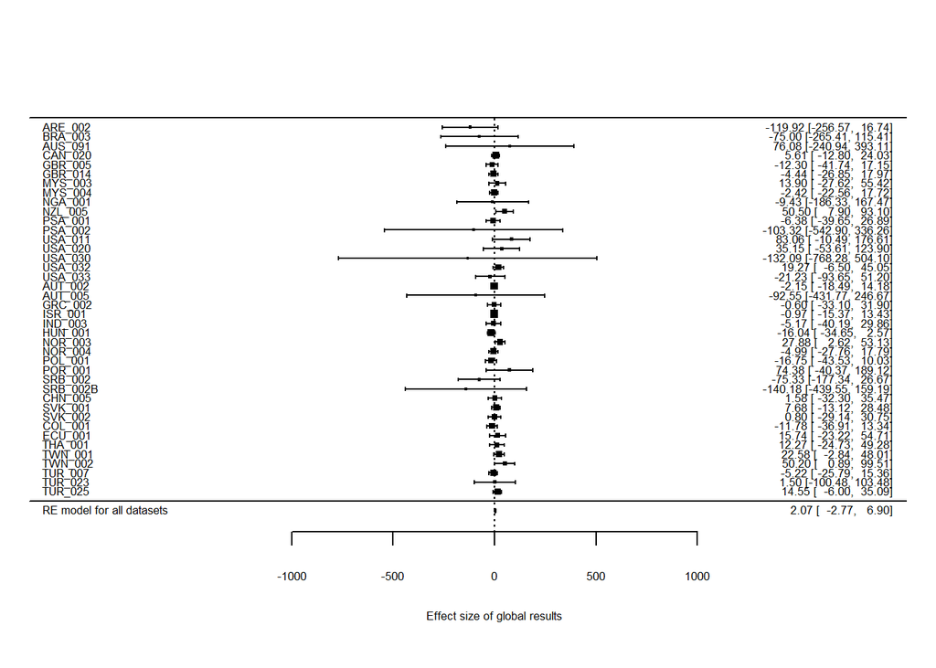

```r
es_data <- SP_V_meta_data %>%
  filter((ni > 25)) ## Exclude small sample size
SP_V_en_es <- escalc(measure = "MC",
         m1i = m_mismatch, m2i = m_match,
         sd1i = sd_mismatch, sd2i = sd_match,
         ni = ni, ri = ri,
         slab = PSA_ID, data=es_data)
SP_V_meta <-  rma.uni(yi, vi, data = SP_V_en_es, slab = PSA_ID, method = "REML", digits = 2)

forest(SP_V_meta, xlab = "Effect size of global results", mlab = "RE model for all datasets")
```

The overall effect was positive but weak based on the meta analysis across all the laboratory data set.

When we considered the data sets from the sites only, the meta analysis revealed the consistent estimation.

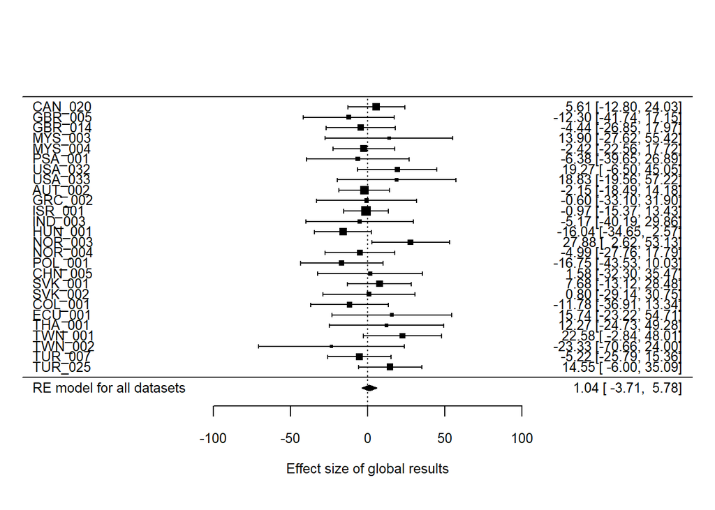

```r
es_data <- SP_V_site_meta_data %>%
  filter((ni > 25)) ## Exclude small sample size
SP_V_site_es <- escalc(measure = "MC",
         m1i = m_mismatch, m2i = m_match,
         sd1i = sd_mismatch, sd2i = sd_match,
         ni = ni, ri = ri,
         slab = PSA_ID, data=es_data)
SP_V_meta <-  rma.uni(yi, vi, data = SP_V_site_es, slab = PSA_ID, method = "REML", digits = 2)

forest(SP_V_meta, xlab = "Effect size of global results", mlab = "RE model for all datasets")
```

The meta analysis on the data collected from websites showed a reversed pattern. It indicated that the orientation effect tended to negative when the data collection was out of the sites.

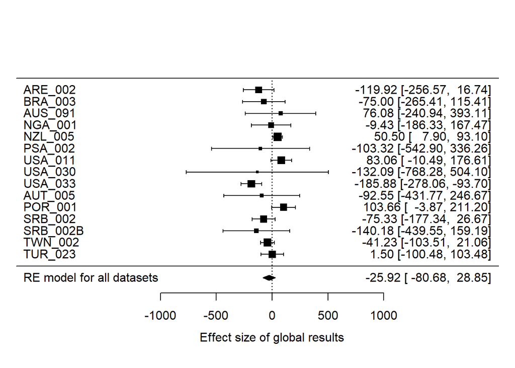

```r
es_data <- SP_V_osweb_meta_data %>%
  filter((ni > 25)) ## Exclude small sample size
SP_V_osweb_es <- escalc(measure = "MC",
         m1i = m_mismatch, m2i = m_match,
         sd1i = sd_mismatch, sd2i = sd_match,
         ni = ni, ri = ri,
         slab = PSA_ID, data=es_data)
SP_V_meta <-  rma.uni(yi, vi, data = SP_V_osweb_es, slab = PSA_ID, method = "REML", digits = 2)

forest(SP_V_meta, xlab = "Effect size of global results", mlab = "RE model for all datasets")
```

### Compare effect size by site and by osweb

In use of the method demonstrated on the [metafor site](https://www.metafor-project.org/doku.php/tips:comp_two_independent_estimates), we compared the estimated effect size across data sources. The result showed neither data source had a larger or smaller effect size, and the estimated effect size was not significant different between the data sources. However, the variance of osweb data was significant larger than that of site data.

```r
SP_V_combine_es <- bind_rows(bind_cols(Source="site",SP_V_site_es),bind_cols(Source="osweb",SP_V_osweb_es))
rma.mv(yi, vi, mods = ~ Source, random = ~ Source | PSA_ID, struct="DIAG", data=SP_V_combine_es, digits=3)
```

```
##
## Multivariate Meta-Analysis Model (k = 41; method: REML)
##
## Variance Components:
##
## outer factor: PSA_ID (nlvls = 39)
## inner factor: Source (nlvls = 2)
##
##               estim    sqrt  k.lvl  fixed  level
## tau^2.1    5619.851  74.966     15     no  osweb
## tau^2.2       0.000   0.002     26     no   site
##
## Test for Residual Heterogeneity:
## QE(df = 39) = 59.283, p-val = 0.020
##
## Test of Moderators (coefficient 2):
## QM(df = 1) = 0.923, p-val = 0.337
##
## Model Results:
##
##             estimate      se    zval   pval    ci.lb   ci.ub
## intrcpt      -25.917  27.942  -0.928  0.354  -80.683  28.849
## Sourcesite    26.952  28.047   0.961  0.337  -28.019  81.924
##
## ---
## Signif. codes:  0 '***' 0.001 '**' 0.01 '*' 0.05 '.' 0.1 ' ' 1
```

```r
res1 <- rma.mv(yi, vi, mods = ~ Source, random = ~ Source | PSA_ID, struct="DIAG", data=SP_V_combine_es)
res0 <- rma.mv(yi, vi, mods = ~ Source, random = ~ Source | PSA_ID, struct="ID",   data=SP_V_combine_es)
anova(res1, res0)
```

```
##
##         df      AIC      BIC     AICc    logLik     LRT   pval      QE
## Full     4 378.2019 384.8561 379.3783 -185.1009                59.2825
## Reduced  3 391.3012 396.2919 391.9869 -192.6506 15.0994 0.0001 59.2825
```

### Analysis of particular langauge data in isolated Rmd

## 3. Estimate a general orientation effect

“In the mixed-effect model, we treat the laboratory and language as random effects and the match advantage of object orientations as a fixed effect.”

### Planned analysis

We at first conducted the model with four random effects: participants, targets, laboratories, and languages.

> Note. This model has the convergence problem. This analysis does not consider this model due to two zero random effects: “Target”, “Langaue”.

```r
SP_V_lme_data <- SP_V_tidy %>%
mutate(Subject = paste0(Source,"_",PSA_ID,"_",subject_nr))

SP_all_random.lmer = lmer(response_time ~ Match + (1|Subject) + (1|Target) + (1|PSA_ID) + (1|Language), data = SP_V_lme_data) ## build mixed-effects regression
summary(SP_all_random.lmer)
```

```
## Linear mixed model fit by REML. t-tests use Satterthwaite's method [
## lmerModLmerTest]
## Formula: response_time ~ Match + (1 | Subject) + (1 | Target) + (1 | PSA_ID) +
##     (1 | Language)
##    Data: SP_V_lme_data
##
## REML criterion at convergence: 1476341
##
## Scaled residuals:
##     Min      1Q  Median      3Q     Max
##  -0.485  -0.126  -0.036   0.016 105.638
##
## Random effects:
##  Groups   Name        Variance Std.Dev.
##  Subject  (Intercept)    25323  159.1
##  PSA_ID   (Intercept)   184746  429.8
##  Target   (Intercept)        0    0.0
##  Language (Intercept)        0    0.0
##  Residual             19797466 4449.4
## Number of obs: 75164, groups:
## Subject, 3351; PSA_ID, 50; Target, 48; Language, 18
##
## Fixed effects:
##             Estimate Std. Error       df t value Pr(>|t|)
## (Intercept)  1004.96      66.04    56.38   15.22   <2e-16 ***
## MatchY         12.65      32.46 72186.69    0.39    0.697
## ---
## Signif. codes:  0 '***' 0.001 '**' 0.01 '*' 0.05 '.' 0.1 ' ' 1
##
## Correlation of Fixed Effects:
##        (Intr)
## MatchY -0.246
## optimizer (nloptwrap) convergence code: 0 (OK)
## boundary (singular) fit: see ?isSingular
```

We found the targets and languages were 0 because these items were tested within participant across matching and mismatching condition. According to the rules for determining the random effect structure (Barr et al., 2013), the model unnecessarily enter the units into the random structure when the units were independent with each other. Therefore we conducted the model excluded the targets and languages from the random effect structure. The analysis indicated a weak overall orientation effect.

```r
# export data file for the making of appendix
SP_V_lme_data %>% select(response_time, Match, Subject, PSA_ID) %>%
write.csv(file = "lme_datafiles/SP_V_lme_data.csv",row.names = FALSE)

SP_reduced_random.lmer = lmer(response_time ~ Match + (1|Subject) + (1|PSA_ID), data = SP_V_lme_data)
#####SP_slope_nocor_reduced_random.lmer = lmer(response_time ~ Match + (1|Subject) + (Match||PSA_ID), data = SP_V_lme_data)
#####SP_slope_cor_reduced_random.lmer = lmer(response_time ~ Match + (1|Subject) + (Match|PSA_ID), data = SP_V_lme_data)

#####anova(SP_reduced_random.lmer, SP_slope_nocor_reduced_random.lmer)  ## better fit: SP_reduced_random.lmer
#####anova(SP_reduced_random.lmer, SP_slope_cor_reduced_random.lmer)  ##  better fit: SP_reduced_random.lmer

summary(SP_reduced_random.lmer)             ## convergence success
```

```
## Linear mixed model fit by REML. t-tests use Satterthwaite's method [
## lmerModLmerTest]
## Formula: response_time ~ Match + (1 | Subject) + (1 | PSA_ID)
##    Data: SP_V_lme_data
##
## REML criterion at convergence: 1476341
##
## Scaled residuals:
##     Min      1Q  Median      3Q     Max
##  -0.485  -0.126  -0.036   0.016 105.638
##
## Random effects:
##  Groups   Name        Variance Std.Dev.
##  Subject  (Intercept)    25326  159.1
##  PSA_ID   (Intercept)   184744  429.8
##  Residual             19797462 4449.4
## Number of obs: 75164, groups:  Subject, 3351; PSA_ID, 50
##
## Fixed effects:
##             Estimate Std. Error       df t value Pr(>|t|)
## (Intercept)  1004.96      66.04    56.38   15.22   <2e-16 ***
## MatchY         12.65      32.46 72186.89    0.39    0.697
## ---
## Signif. codes:  0 '***' 0.001 '**' 0.01 '*' 0.05 '.' 0.1 ' ' 1
##
## Correlation of Fixed Effects:
##        (Intr)
## MatchY -0.246
```

Concerned the shift of data collection method, we conducted the mixed-effect model with the fixed effect of data source. In this model the languages are nonindependent from the data source, thus the language was treated as one random effect. The analysis indicated that the responses collected in sites were faster than the responses collected on the website. As like the previous models, the overall orientation effect was weak and had no interaction with the data source.

### Analysis included data source

Our study had to altered the data collection method from sites to from Internet due to the pandemic situation. We conducted the mixed-effect model included the orientation effect and data source as the fixed effects. According to [Jake Westfall’s suggestion on Stackoverflow](https://stats.stackexchange.com/questions/361681/mixed-effects-model-compare-random-variance-component-across-levels-of-a-groupi), we conducted two mixed-effect models included data source as the random slopes. One model computed had the correlations of data source and the other random effects (teams, languages), and the other had no the correlations. Each model indicated the significant difference between the sites and Internet and no interaction of the orientation effect and the data sources. The results was consistent with the meta analysis on the estimated effect size and with the published mega studies comparing the results from sites and from Internet (Anwyl-Irvine et al., 2020; Bridges et al., 2020).

> Note. The best fitted model `source_cor.lmer` has the convergence problem.

```r
SP_V_lme_data$r_Source = if_else(SP_V_lme_data$Source == "site",1,-1)

#####source_zero_slope_nocor.lmer =lmer(response_time ~ Match*r_Source + (1|Subject) + (1|PSA_ID) + (1|Language), data = SP_V_lme_data)


#####source_nocor.lmer =lmer(response_time ~ Match*r_Source + (1|Subject) + (r_Source||PSA_ID) + (r_Source||Language), data = SP_V_lme_data)

#####source_cor.lmer =lmer(response_time ~ Match*r_Source + (1|Subject) + (r_Source|PSA_ID) + (r_Source|Language), data = SP_V_lme_data)

#####anova(source_zero_slope_nocor.lmer, source_nocor.lmer)  ## better fit: source_zero_slope_nocor.lmer
#####anova(source_zero_slope_nocor.lmer, source_cor.lmer)  ## better fit: source_cor.lmer
#####anova(source_nocor.lmer, source_cor.lmer)  ## better fit: source_cor.lmer

#####summary(source_cor.lmer)  ## convergence singular?


#####source_cor.lmer.all <- allFit(source_cor.lmer)
#####source_cor.lmer.all.ss <- summary(source_cor.lmer.all)
#####source_cor.lmer.all.ss$msgs   ## all optimizers showed signular warnings

## Change the optimizer
source_cor.lmer <- lmerTest::lmer(
  response_time ~ Match*r_Source +
    (1|Subject) +
    (r_Source|PSA_ID) +
    (r_Source|Language),
  control = lmerControl(optimizer = "bobyqa",
                        optCtrl = list(maxfun = 1e6)),
  data = SP_V_lme_data)

summary(source_cor.lmer)
```

```
## Linear mixed model fit by REML. t-tests use Satterthwaite's method [
## lmerModLmerTest]
## Formula: response_time ~ Match * r_Source + (1 | Subject) + (r_Source |
##     PSA_ID) + (r_Source | Language)
##    Data: SP_V_lme_data
## Control: lmerControl(optimizer = "bobyqa", optCtrl = list(maxfun = 1e+06))
##
## REML criterion at convergence: 1476179
##
## Scaled residuals:
##     Min      1Q  Median      3Q     Max
##  -0.424  -0.148  -0.032   0.022 105.706
##
## Random effects:
##  Groups   Name        Variance Std.Dev. Corr
##  Subject  (Intercept)    12540  111.98
##  PSA_ID   (Intercept)     3717   60.97
##           r_Source        3671   60.59  -1.00
##  Language (Intercept)    18682  136.68
##           r_Source       15591  124.86  -1.00
##  Residual             19798299 4449.53
## Number of obs: 75164, groups:  Subject, 3351; PSA_ID, 50; Language, 18
##
## Fixed effects:
##                  Estimate Std. Error        df t value Pr(>|t|)
## (Intercept)      1144.635     55.145    10.519  20.757 7.08e-10 ***
## MatchY             16.869     33.122 72181.151   0.509    0.611
## r_Source         -445.890     53.163     9.289  -8.387 1.24e-05 ***
## MatchY:r_Source   -21.190     33.122 72181.140  -0.640    0.522
## ---
## Signif. codes:  0 '***' 0.001 '**' 0.01 '*' 0.05 '.' 0.1 ' ' 1
##
## Correlation of Fixed Effects:
##             (Intr) MatchY r_Sorc
## MatchY      -0.301
## r_Source    -0.848  0.062
## MtchY:r_Src  0.060 -0.199 -0.312
## optimizer (bobyqa) convergence code: 0 (OK)
## boundary (singular) fit: see ?isSingular
```

```r
#source_cor.lmer.all.ss$llik  ## vector of log-likelihoods
#source_cor.lmer.all.ss$fixef ## table of fixed effects
#source_cor.lmer.all.ss$sdcor ## table of random effect SDs and correlations
#source_cor.lmer.all.ss$theta ## table of random effects parameters, Cholesky scale
```

The interaction plot by `source_cor.lmer` indicated the longer response times for “osweb”(-1) than “site”(1). Both sources showed the null orientation effect. We better elaborate the orientation effect from two data sources respectively.

> Note. Because we have conducted `source_cor.lmer.all`, is there some way we plot the model based on this object.

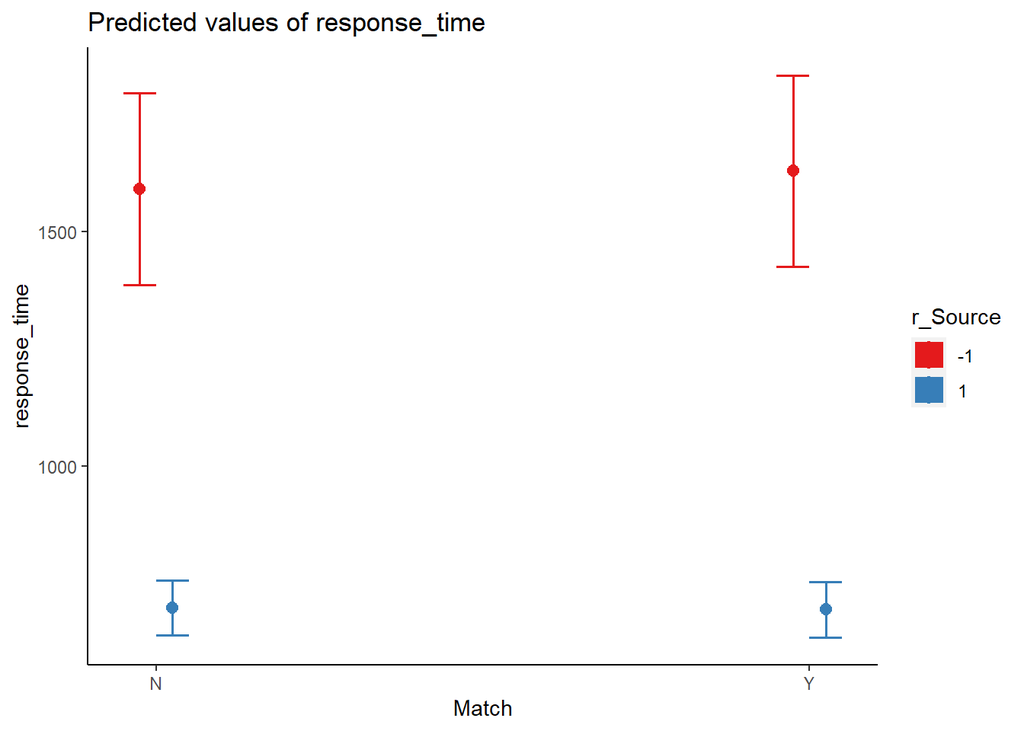

```r
# Plot interaction

sjPlot::plot_model(source_cor.lmer,
                   type = "pred",
                   terms = c('Match', 'r_Source'),
                   ci.lvl = .95) +
#  geom_point() +
  guides(color=guide_legend(override.aes = list(size = 6))) +
  theme(panel.grid.major = element_blank(),
        panel.grid.minor = element_blank(),
        panel.background = element_blank(),
        axis.line = element_line(colour = "black"))
```

### Effect X languages interactions

We analyzed the interactions by the data sources separately.

- Site data

```r
## Allocate the site data
SP_V_site_lme_data = subset(SP_V_lme_data, Source=="site")

## Run the mixed effect model by site data
site_cor.lmer =lmer(response_time ~ Language*Match + (1|Subject),
  control = lmerControl(optimizer = "bobyqa",
                        optCtrl = list(maxfun = 1e6)),
  data = SP_V_site_lme_data)
#####site_slope_nocor.lmer =lmer(response_time ~ Language*Match + (Match||Subject), data = SP_V_site_lme_data)
#####site_slope_cor.lmer =lmer(response_time ~ Language*Match + (Match|Subject), data = SP_V_site_lme_data)


#####anova(site_cor.lmer,site_slope_nocor.lmer) ## better fit: site_cor.lmer
#####anova(site_cor.lmer,site_slope_cor.lmer)   ## better fit: site_cor.lmer

summary(site_cor.lmer)               ## convergence success
```

```
## Linear mixed model fit by REML. t-tests use Satterthwaite's method [
## lmerModLmerTest]
## Formula: response_time ~ Language * Match + (1 | Subject)
##    Data: SP_V_site_lme_data
## Control: lmerControl(optimizer = "bobyqa", optCtrl = list(maxfun = 1e+06))
##
## REML criterion at convergence: 613476.9
##
## Scaled residuals:
##     Min      1Q  Median      3Q     Max
## -4.1041 -0.6023 -0.1906  0.4056  6.3293
##
## Random effects:
##  Groups   Name        Variance Std.Dev.
##  Subject  (Intercept) 22531    150.1
##  Residual             42981    207.3
## Number of obs: 45060, groups:  Subject, 2014
##
## Fixed effects:
##                                      Estimate Std. Error         df t value
## (Intercept)                          670.1812     6.5644  2305.3423 102.094
## LanguageGerman                       -29.1429    17.5666  2286.2231  -1.659
## LanguageGreek                        176.2288    17.7360  2333.5903   9.936
## LanguageHebrew                       -16.5390    14.9359  2286.4718  -1.107
## LanguageHindi                         95.7291    19.5033  2341.0257   4.908
## LanguageMagyar                        41.0354    15.7186  2291.2445   2.611
## LanguageNorwegian                      4.0091    16.0226  2285.7803   0.250
## LanguagePolish                         3.6101    23.8625  2290.0043   0.151
## LanguagePortuguese                   -48.8879    72.7393  2275.7629  -0.672
## LanguageSimple Chinese                78.7687    19.2542  2324.4452   4.091
## LanguageSlovak                        20.9894    15.3059  2295.7832   1.371
## LanguageSpanish                       94.9524    15.8723  2320.6996   5.982
## LanguageThai                          58.3223    23.9362  2317.6942   2.437
## LanguageTraditional Chinese           33.9599    18.0770  2300.8226   1.879
## LanguageTurkish                       55.3693    13.6824  2299.9103   4.047
## MatchY                                -6.6800     3.5483 43036.6131  -1.883
## LanguageGerman:MatchY                 -7.0850     9.3973 43025.4194  -0.754
## LanguageGreek:MatchY                 -17.3096     9.7315 43051.5617  -1.779
## LanguageHebrew:MatchY                  2.0694     8.0000 43027.3139   0.259
## LanguageHindi:MatchY                  17.2725    10.7600 43058.2142   1.605
```

[output cut: 28 more lines]

```
## LanguageGreek:MatchY                 0.0753 .
## LanguageHebrew:MatchY                0.7959
## LanguageHindi:MatchY                 0.1084
## LanguageMagyar:MatchY                0.1202
## LanguageNorwegian:MatchY             0.8990
## LanguagePolish:MatchY                0.7088
## LanguagePortuguese:MatchY            0.8230
## LanguageSimple Chinese:MatchY        0.3706
## LanguageSlovak:MatchY                0.8486
## LanguageSpanish:MatchY               0.4522
## LanguageThai:MatchY                  0.8576
## LanguageTraditional Chinese:MatchY   0.9499
## LanguageTurkish:MatchY               0.0779 .
## ---
## Signif. codes:  0 '***' 0.001 '**' 0.01 '*' 0.05 '.' 0.1 ' ' 1
```

Model plot shows the variance of response time among languages. The slowest group (Greek) had the longer average response times than the faster groups (English, German, Hebrew).

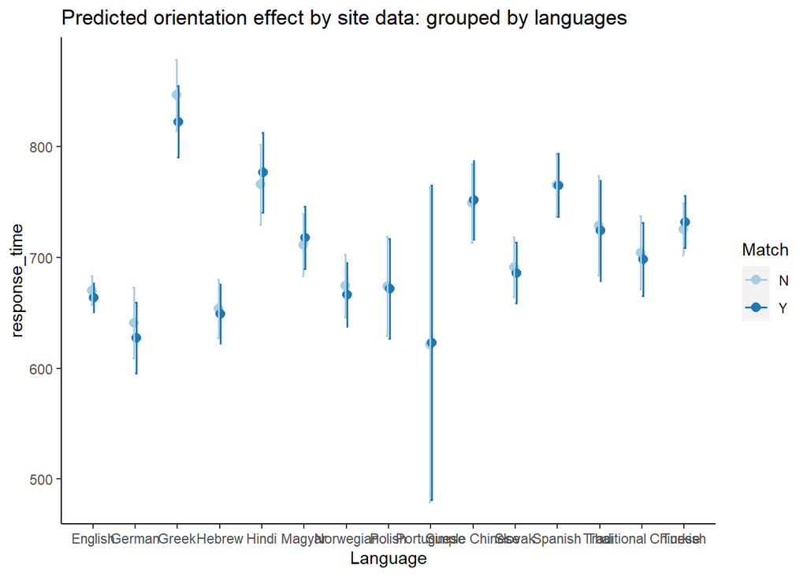

```r
# Plot interaction

sjPlot::plot_model(site_cor.lmer,
                   type = "pred",
                   terms = c('Language', 'Match'),
                   ci.lvl = .95,
                   colors = "Paired",
                   title = "Predicted orientation effect by site data: grouped by languages") +
#scale_fill_gradientn(colours=topo.colors(15)) +
#  geom_point() +
#  guides(color=guide_legend(override.aes = list(size = 6))) +
  theme(panel.grid.major = element_blank(),
        panel.grid.minor = element_blank(),
        panel.background = element_blank(),
        axis.line = element_line(colour = "black"))
```

- Osweb data

> Note. The best fitted model `osweb_slope_nocor.lmer` has the convergence problem.

```r
## Allocate the site data
SP_V_osweb_lme_data = subset(SP_V_lme_data, Source=="osweb")


## Run the mixed effect model by site data
#####osweb_cor.lmer =lmer(response_time ~ Language*Match + (1|Subject), data = SP_V_osweb_lme_data)
#####osweb_slope_nocor.lmer =lmer(response_time ~ Language*Match + (Match||Subject), data = SP_V_osweb_lme_data)
#####osweb_slope_cor.lmer =lmer(response_time ~ Language*Match + (Match|Subject), data = SP_V_osweb_lme_data)

#####anova(osweb_cor.lmer,osweb_slope_nocor.lmer) ## better fit: osweb_slope_nocor.lmer
#####anova(osweb_slope_nocor.lmer,osweb_slope_cor.lmer)   ## better fit: osweb_slope_nocor.lmer

#####summary(osweb_slope_nocor.lmer)       ## convergence failed

#####osweb_slope_nocor.lmer.all <- allFit(osweb_slope_nocor.lmer)
#####osweb_slope_nocor.lmer.all.ss <- summary(source_cor.lmer.all)

#####osweb_slope_nocor.lmer.all.ss$msgs    ## all optimizers showed warnings?

#osweb_slope_nocor.lmer.all.ss$llik  ## vector of log-likelihoods

osweb_slope_nocor.lmer = lmerTest::lmer(response_time ~ Language*Match + (Match||Subject),
  control = lmerControl(optimizer = "bobyqa",
                        optCtrl = list(maxfun = 1e6)), # Increase maximum number of iterations to facilitate model convergence ,
                    data = SP_V_osweb_lme_data)

summary(osweb_slope_nocor.lmer)
```

```
## Linear mixed model fit by REML. t-tests use Satterthwaite's method [
## lmerModLmerTest]
## Formula: response_time ~ Language * Match + (Match || Subject)
##    Data: SP_V_osweb_lme_data
## Control: lmerControl(optimizer = "bobyqa", optCtrl = list(maxfun = 1e+06))
##
## REML criterion at convergence: 618462.3
##
## Scaled residuals:
##    Min     1Q Median     3Q    Max
## -1.126 -0.148 -0.116 -0.017 66.294
##
## Random effects:
##  Groups    Name        Variance  Std.Dev. Corr
##  Subject   (Intercept) 0.000e+00    0.00
##  Subject.1 MatchN      8.466e+05  920.10
##            MatchY      1.036e+02   10.18  -1.00
##  Residual              4.897e+07 6997.68
## Number of obs: 30104, groups:  Subject, 1337
##
## Fixed effects:
##                                     Estimate Std. Error      df t value
## (Intercept)                          1160.48     282.28 1441.50   4.111
## LanguageBrazilian Portuguese          338.47     430.27 1373.85   0.787
## LanguageEnglish                       341.66     294.34 1433.86   1.161
## LanguageGerman                        403.33     343.31 1395.23   1.175
## LanguageNorwegian                     553.23     567.85 1331.09   0.974
## LanguagePortuguese                    448.05     417.14 1359.31   1.074
## LanguageSerbian                       977.55     346.90 1407.63   2.818
## LanguageTraditional Chinese           -58.74     414.70 1405.09  -0.142
## LanguageTurkish                       778.90     385.19 1398.84   2.022
## MatchY                                164.94     382.27 2408.61   0.431
## LanguageBrazilian Portuguese:MatchY   -37.81     583.13 2302.47  -0.065
## LanguageEnglish:MatchY               -151.42     398.64 2396.43  -0.380
## LanguageGerman:MatchY                  76.26     465.18 2335.54   0.164
## LanguageNorwegian:MatchY             -298.22     771.16 2245.00  -0.387
## LanguagePortuguese:MatchY              98.85     565.95 2286.35   0.175
## LanguageSerbian:MatchY               -443.40     469.63 2349.01  -0.944
## LanguageTraditional Chinese:MatchY    -89.59     560.96 2336.45  -0.160
## LanguageTurkish:MatchY                -30.74     522.25 2347.10  -0.059
```

[output cut: 8 more lines]

```
## LanguageTraditional Chinese           0.8874
## LanguageTurkish                       0.0434 *
## MatchY                                0.6662
## LanguageBrazilian Portuguese:MatchY   0.9483
## LanguageEnglish:MatchY                0.7041
## LanguageGerman:MatchY                 0.8698
## LanguageNorwegian:MatchY              0.6990
## LanguagePortuguese:MatchY             0.8614
## LanguageSerbian:MatchY                0.3452
## LanguageTraditional Chinese:MatchY    0.8731
## LanguageTurkish:MatchY                0.9531
## ---
## Signif. codes:  0 '***' 0.001 '**' 0.01 '*' 0.05 '.' 0.1 ' ' 1
## optimizer (bobyqa) convergence code: 0 (OK)
## boundary (singular) fit: see ?isSingular
```

```r
#osweb_slope_nocor.lmer.all.ss$llik  ## vector of log-likelihoods
#osweb_slope_nocor.lmer.all.ss$fixef ## table of fixed effects
#osweb_slope_nocor.lmer.all.ss$sdcor ## table of random effect SDs and correlations
#osweb_slope_nocor.lmer.all.ss$theta ## table of random effects parameters, Cholesky scale
```

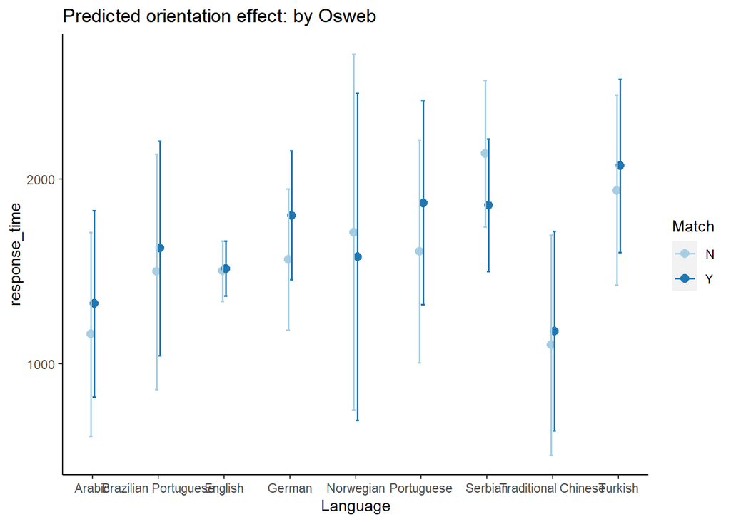

```r
# Plot interaction

sjPlot::plot_model(osweb_slope_nocor.lmer,
                   type = "pred",
                   terms = c('Language', 'Match'),
                   ci.lvl = .95,
                   colors = "Paired",
                   title = "Predicted orientation effect: by Osweb") +
#scale_fill_gradientn(colours=topo.colors(15)) +
#  geom_point() +
#  guides(color=guide_legend(override.aes = list(size = 6))) +
  theme(panel.grid.major = element_blank(),
        panel.grid.minor = element_blank(),
        panel.background = element_blank(),
        axis.line = element_line(colour = "black"))
```

### Exploratory analysis on the English orientation effects

Count the available participants from each English teams.

```r
SP_V_tidy %>%
  mutate(Subject = paste0(Source,"_",PSA_ID,"_",subject_nr)) %>%
  filter(Language == "English") %>%
  group_by(Source, PSA_ID) %>%
  count(Subject) %>%
  select(PSA_ID,Source) %>%
  table()
```

```
##           Source
## PSA_ID     osweb site
##   AUS_091    159    0
##   CAN_020      0   97
##   GBR_005      0   52
##   GBR_006      0   25
##   GBR_014      0   50
##   GBR_043      0   25
##   MYS_003      0   47
##   MYS_004      0  100
##   NGA_001     48    0
##   NZL_005    311    0
##   PSA_001      0   41
##   PSA_002     64    0
##   TUR_007E     0    8
##   TWN_002E    12    0
##   USA_011     60    0
##   USA_020     25   23
##   USA_030     26    0
##   USA_032      0   50
##   USA_033     45   31
##   USA_065      0   32
##   USA_173      0   32
```

Two team (TUR_007E, TWN_002E) have to be excluded because they were the bilingual participants in addition to their default language.

```r
SP_V_eng_tidy <- SP_V_tidy %>%
  filter(Language == "English",!(PSA_ID %in% c("TUR_007E", "TWN_002E"))) %>%
  mutate(Subject = paste0(Source,"_",PSA_ID,"_",subject_nr)) %>%
  mutate(System = if_else(grepl(PSA_ID,pattern = "^PSA|^USA"),"US","UK")) %>%
  separate(PSA_ID,sep = "_",into = c("Country","LAB_ID")) %>%
  mutate(PSA_ID = paste0(Country,"_",LAB_ID))

## Export data file for making of appendix
SP_V_eng_tidy %>% select(response_time, Match, System,Source,Subject,Target,PSA_ID) %>%
  write.csv(file = "lme_datafiles/SP_V_eng_tidy.csv")
```

Mixed-effect models evaluated the fixed effects of matching, English systems(US/UK), and data sources(sites/osweb) in terms of the random intercepts of participants, targets, and teams as well as the random slopes of teams with langauge systems and data sources.

> Note. The best fitted model `eng_no_slope.lmer` has the convergence problem.

```r
SP_V_eng_tidy$r_System = if_else(SP_V_eng_tidy$System == "US",1,-1)
SP_V_eng_tidy$r_Source = if_else(SP_V_eng_tidy$Source == "site",1,-1)

#####eng_no_slope.lmer =lmer(response_time ~ Match*r_System*r_Source + (1|Subject) + (1|Target) + (1|PSA_ID), data = SP_V_eng_tidy)


#####eng_no_cor.lmer =lmer(response_time ~ Match*r_System*r_Source + (1|Subject) + (1|Target) + (r_System||PSA_ID) + (r_Source||PSA_ID), data = SP_V_eng_tidy)

#####eng_cor.lmer =lmer(response_time ~ Match*r_System*r_Source + (1|Subject) + (1|Target) + (r_System|PSA_ID) + (r_Source|PSA_ID), data = SP_V_eng_tidy)

#####anova(eng_no_slope.lmer,eng_no_cor.lmer) ## better fit: eng_no_slope.lmer
#####anova(eng_no_slope.lmer,eng_cor.lmer)    ## better fit: eng_no_slope.lmer

#####summary(eng_no_slope.lmer)   ## convergence singular?

#####eng_no_slope.lmer.all <- allFit(eng_no_slope.lmer)
#####eng_no_slope.lmer.all.ss <- summary(eng_no_slope.lmer.all)
#####eng_no_slope.lmer.all.ss$msgs  ## all optimizers have warnings?


eng_no_slope.lmer = lmerTest::lmer(response_time ~ Match*r_System*r_Source + (1|Subject) + (1|Target) + (1|PSA_ID), control = lmerControl(optimizer = "bobyqa", optCtrl = list(maxfun = 1e6)),  data = SP_V_eng_tidy)

summary(eng_no_slope.lmer)
```

```
## Linear mixed model fit by REML. t-tests use Satterthwaite's method [
## lmerModLmerTest]
## Formula: response_time ~ Match * r_System * r_Source + (1 | Subject) +
##     (1 | Target) + (1 | PSA_ID)
##    Data: SP_V_eng_tidy
## Control: lmerControl(optimizer = "bobyqa", optCtrl = list(maxfun = 1e+06))
##
## REML criterion at convergence: 604087.7
##
## Scaled residuals:
##    Min     1Q Median     3Q    Max
## -0.303 -0.155 -0.035  0.016 86.497
##
## Random effects:
##  Groups   Name        Variance Std.Dev.
##  Subject  (Intercept)    21329  146.04
##  Target   (Intercept)     6618   81.35
##  PSA_ID   (Intercept)        0    0.00
##  Residual             29544017 5435.44
## Number of obs: 30148, groups:  Subject, 1343; Target, 48; PSA_ID, 19
##
## Fixed effects:
##                          Estimate Std. Error       df t value Pr(>|t|)
## (Intercept)               1041.71      49.14   206.72  21.197  < 2e-16 ***
## MatchY                      47.74      67.20 28892.41   0.710   0.4775
## r_System                  -105.85      47.72  4822.67  -2.218   0.0266 *
## r_Source                  -377.08      47.72  4822.55  -7.902 3.38e-15 ***
## MatchY:r_System            106.25      67.20 28900.04   1.581   0.1139
## MatchY:r_Source            -58.35      67.20 28891.08  -0.868   0.3852
## r_System:r_Source          100.84      47.72  4823.96   2.113   0.0346 *
## MatchY:r_System:r_Source  -112.33      67.21 28914.32  -1.671   0.0947 .
## ---
## Signif. codes:  0 '***' 0.001 '**' 0.01 '*' 0.05 '.' 0.1 ' ' 1
##
## Correlation of Fixed Effects:
##             (Intr) MatchY r_Syst r_Sorc MtchY:r_Sy MtchY:r_Sr r_S:_S
## MatchY      -0.684
## r_System     0.336 -0.243
## r_Source     0.062 -0.045 -0.025
## MtchY:r_Sys -0.236  0.348 -0.704  0.017
## MtchY:r_Src -0.044  0.065  0.017 -0.704 -0.022
## r_Systm:r_S -0.024  0.017  0.064  0.346 -0.045     -0.243
## MtchY:_S:_S  0.017 -0.021 -0.045 -0.243  0.065      0.348     -0.704
## optimizer (bobyqa) convergence code: 0 (OK)
## boundary (singular) fit: see ?isSingular
```

```r
#eng_no_slope.lmer.all.ss$llik  ## vector of log-likelihoods
#eng_no_slope.lmer.all.ss$fixef ## table of fixed effects
#eng_no_slope.lmer.all.ss$sdcor ## table of random effect SDs and correlations
#eng_no_slope.lmer.all.ss$theta ## table of random effects parameters, Cholesky scale
```

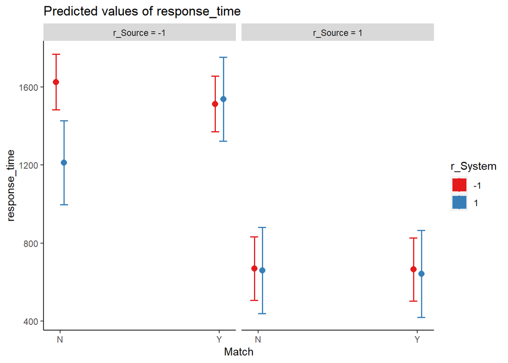

```r
# Plot interaction

sjPlot::plot_model(eng_no_slope.lmer,
                   type = "pred",
                   terms = c('Match', 'r_System', 'r_Source'),
                   ci.lvl = .95) +
#  geom_point() +
  guides(color=guide_legend(override.aes = list(size = 6))) +
  theme(panel.grid.major = element_blank(),
        panel.grid.minor = element_blank(),
        panel.background = element_blank(),
        axis.line = element_line(colour = "black"))
```

Neither American English nor British English showed the significant orientation effect based on which data source. Overall pattern may show taht British English had more advantage than American English.

## 4. Analysis on imagery scores

### Overall estimation and test

“… we compute an imagery score by taking the elapsed verification time between the orientation settings of critical object pictures (identical, different).”

**initial assumption** Imagery scores (elapsed responses times from different to identical orientation settings) are the dependent measurement of picture-picture verification task. Initially we assumed the results of every language group would be nearly equal. Our exploratory goal is to test the predictions of imagery scores on the orientation effect.

Below table we summarized the imagery scores from the data excluded the outliers we identified in the first part: “Identify the outliers in each data set”.

```r
## Dataset for traditional ANOVA
PP_aov_data <- PP_tidy %>% left_join(outliers_table, by=c("PSA_ID" = "LAB", "subject_nr" = "subject_nr")) %>%  ## filter the outliers by SP_V data
  filter(Outlier == FALSE) %>%
mutate(Subject = paste0(Source,"_",PSA_ID,"_",subject_nr)) %>%
  group_by(Source, Language, PSA_ID, Subject, Identical) %>%
  summarise(subject_M = median(response_time), subject_ACC = n()/12)

## Dataset for mixed-effect model
PP_lme_data <- PP_tidy %>% left_join(outliers_table, by=c("PSA_ID" = "LAB", "subject_nr" = "subject_nr")) %>%  ## filter the outliers by SP_V data
  filter(Outlier == FALSE) %>%
mutate(Subject = paste0(Source,"_",PSA_ID,"_",subject_nr))

##
PP_aov_data %>% group_by(Language, Identical) %>%
  summarise(N = n(), med_RT = median(subject_M), mean_ACC = mean(subject_ACC)) %>%
  pivot_wider(names_from = Identical, values_from = c(med_RT, mean_ACC)) %>%
  mutate(Imagery = (med_RT_N - med_RT_Y) ) %>%
  transmute( N=N,
             Mismatch_stat = paste0(round(med_RT_N),"(",round(mean_ACC_N*100,2),")"),
             Match_stat = paste0(round(med_RT_Y),"(",round(mean_ACC_Y*100,2),")"),
             Imagery = Imagery) %>%
  flextable() %>%
  set_header_labels(Language = "Language", N = "N", Mismatch_stat ="Different", Match_stat = "Identical", Effect = "Imagery Score")
```

| Language | N | Different | Identical | Imagery |
| --- | --- | --- | --- | --- |
| Arabic | 51 | 584(94.93) | 532(96.9) | 52.00 |
| Brazilian Portuguese | 49 | 631(96.09) | 598(98.81) | 32.50 |
| English | 1,087 | 582(94.29) | 545(97.66) | 37.50 |
| German | 201 | 580(94.53) | 546(97.68) | 34.00 |
| Greek | 73 | 627(94.63) | 580(98.52) | 47.50 |
| Hebrew | 108 | 594(97.22) | 560(98.61) | 33.00 |
| Hindi | 58 | 652(96.55) | 603(98.42) | 49.25 |
| Magyar | 97 | 598(96.56) | 572(98.71) | 26.50 |
| Norwegian | 107 | 612(94.63) | 574(98.52) | 38.00 |
| Polish | 37 | 569(96.62) | 527(99.1) | 42.00 |
| Portuguese | 44 | 598(95.64) | 561(98.86) | 36.75 |
| Serbian | 109 | 595(95.11) | 560(98.78) | 35.00 |
| Simple Chinese | 59 | 616(95.62) | 562(97.88) | 53.50 |
| Slovak | 103 | 600(95.87) | 558(98.62) | 41.50 |
| Spanish | 95 | 660(92.02) | 607(96.32) | 53.00 |
| Thai | 37 | 590(94.82) | 542(99.1) | 47.50 |
| Traditional Chinese | 112 | 585(95.24) | 553(98.59) | 31.75 |
| Turkish | 194 | 643(94.8) | 598(98.24) | 45.50 |

### Imagery scores among the languages and the laboratories

“The first step compares the imagery scores among the languages and the laboratories with the analysis of variance. The results will indicate the generalizability of mental rotation among languages.”

- Traditional ANOVA

Because languages and laboratories are nonindependent with each other, we analyzed each interaction with orientation setting (presented pictures in same/different orientations) separately.

The traditional ANOVA of languages and orientation setting indicated the interaction which means the imagery scores were higher in some languages.

```r
PP.1.aov <- aov_car(subject_M ~ Identical*Language + Error(Subject/Identical), data = PP_aov_data)

knitr::kable(nice(PP.1.aov))
```

| Effect | df | MSE | F | ges | p.value |
| --- | --- | --- | --- | --- | --- |
| Language | 17, 2603 | 11379.51 | 11.86 *** | .066 | <.001 |
| Identical | 1, 2603 | 1092.84 | 1029.79 *** | .034 | <.001 |
| Language:Identical | 17, 2603 | 1092.84 | 1.90 * | .001 | .015 |

The traditional ANOVA of laboratories and orientation setting indicated the interaction which means the imagery scores were various among the sites.

```r
PP.2.aov <- aov_car(subject_M ~ Identical*PSA_ID + Error(Subject/Identical), data = PP_aov_data)

knitr::kable(nice(PP.2.aov))
```

| Effect | df | MSE | F | ges | p.value |
| --- | --- | --- | --- | --- | --- |
| PSA_ID | 49, 2571 | 10854.68 | 7.54 *** | .115 | <.001 |
| Identical | 1, 2571 | 1083.60 | 1398.95 *** | .047 | <.001 |
| PSA_ID:Identical | 49, 2571 | 1083.60 | 1.77 *** | .003 | <.001 |

- **mixed-effect model**

Considering the additional data source, we further conducted the mixed-effect model to evaluate the confounding of languages and sites. Our reason depended on our purpose to evaluate results of traditional ANOVA. In the first model, the orientation setting are the only one fixed effect; languages and sites are the random effects. Between the comparisons of the models included the random slopes or intercept-slope correlation, the better fitted model included the random slopes and the intercept-slope correlations. The result indicated that languages and teams influenced little on the overall effect of orientation setting.

> Note. The best fitted model `PP.effect.slopes.lme` has the convergence problem.

```r
## Export data file for the making of appendix
PP_lme_data %>% select(response_time, Identical, Subject, Picture1, PSA_ID, Language) %>%
  write.csv(file = "lme_datafiles/PP_lme_data.csv")


#PP_mixed_data = PP_aov_data
PP_lme_data$recode_Identical = if_else(PP_lme_data$Identical == "Y",1,0)
## standardized the imagery score
PP_lme_data$z_Identical = scale_by(recode_Identical ~ Subject + PSA_ID, data = PP_lme_data)


######PP.effect.zero_slope.lme <- lmerTest::lmer(response_time ~
#####                    z_Identical +                # Fixed effect
#####                    (1 | Subject) +   # By-subject random intercept
#####                    (1 | Picture1) +   # By-item random intercept
#####                    (1 | PSA_ID) +    # By-lab random intercept
#                    (z_Identical || PSA_ID) +    # By-lab random slopes
#####                    (1 | Language),    # By-lab random intercept
#                    (z_Identical || Language),    # By-lab random slopes
#####                    data = PP_lme_data,
                    #method = 'KR',               # Calculate p values using Kenward-Roger method
#####                    control = lmerControl(optCtrl = list(maxfun = 1e6)) # Increase maximum number of iterations to facilitate model convergence
#####                    )


######PP.effect.slopes.lme <- lmerTest::lmer(response_time ~
#####                    z_Identical +                # Fixed effect
#####                    (1 | Subject) +   # By-subject random intercept
#####                    (1 | Picture1) +   # By-item random intercept
#####                    (z_Identical | PSA_ID) +    # By-lab random intercept
#                    (z_Identical || PSA_ID) +    # By-lab random slopes
#####                    (z_Identical | Language),    # By-lab random intercept
#                    (z_Identical || Language),    # By-lab random slopes
#####                    data = PP_lme_data,
                    #method = 'KR',               # Calculate p values using Kenward-Roger method
#####                    control = lmerControl(optCtrl = list(maxfun = 1e6)) # Increase maximum number of iterations to facilitate model convergence
#####                    )



######PP.effect.slopes.nocor.lme <- lmerTest::lmer(response_time ~
#####                    z_Identical +                # Fixed effect
#####                    (1 | Subject) +   # By-subject random intercept
#####                    (1 | Picture1) +   # By-item random intercept
#                    (z_Identical | PSA_ID) +    # By-lab random intercept
#####                    (z_Identical || PSA_ID) +    # By-lab random slopes
#                    (z_Identical | Language),    # By-lab random intercept
#####                    (z_Identical || Language),    # By-lab random slopes
#####                    data = PP_lme_data,
                    #method = 'KR',               # Calculate p values using Kenward-Roger method
#####                    control = lmerControl(optCtrl = list(maxfun = 1e6)) # Increase maximum number of iterations to facilitate model convergence
#####                    )


#####anova(PP.effect.zero_slope.lme,PP.effect.slopes.lme) ## PP.effect.slopes.lme has better fitness
#####anova(PP.effect.slopes.lme,PP.effect.slopes.nocor.lme) ## PP.effect.slopes.lme has better fitness

#####summary(PP.effect.slopes.lme)      ## convergence singular?

#####PP.effect.slopes.lme.all <- allFit(PP.effect.slopes.lme)
#####PP.effect.slopes.lme.all.ss <- summary(PP.effect.slopes.lme.all)
#####PP.effect.slopes.lme.all.ss$msgs  ## Nelder_Mead, nloptwrap.NLOPT_LN_NELDERMEAD failed

#####sort(sapply(PP.effect.slopes.lme.all,logLik))




PP.effect.slopes.lme <- lmerTest::lmer(response_time ~
                    z_Identical +                # Fixed effect
                    (1 | Subject) +   # By-subject random intercept
                    (1 | Picture1) +   # By-item random intercept
                    (z_Identical | PSA_ID) +    # By-lab random intercept
#                    (z_Identical || PSA_ID) +    # By-lab random slopes
                    (z_Identical | Language),    # By-lab random intercept
#                    (z_Identical || Language),    # By-lab random slopes
                    control = lmerControl(optimizer = "bobyqa", optCtrl = list(maxfun = 1e6)), # Increase maximum number of iterations to facilitate model convergence
                    data = PP_lme_data
)

summary(PP.effect.slopes.lme)
```

```
## Linear mixed model fit by REML. t-tests use Satterthwaite's method [
## lmerModLmerTest]
## Formula: response_time ~ z_Identical + (1 | Subject) + (1 | Picture1) +
##     (z_Identical | PSA_ID) + (z_Identical | Language)
##    Data: PP_lme_data
## Control: lmerControl(optimizer = "bobyqa", optCtrl = list(maxfun = 1e+06))
##
## REML criterion at convergence: 755310.3
##
## Scaled residuals:
##     Min      1Q  Median      3Q     Max
## -6.2718 -0.5602 -0.1486  0.3515 11.3760
##
## Random effects:
##  Groups   Name        Variance  Std.Dev. Corr
##  Subject  (Intercept)  5494.356  74.124
##  PSA_ID   (Intercept)   570.156  23.878
##           z_Identical     3.561   1.887  -1.00
##  Picture1 (Intercept)   617.320  24.846
##  Language (Intercept)   341.506  18.480
##           z_Identical     3.768   1.941  -0.44
##  Residual             13499.328 116.187
## Number of obs: 60647, groups:
## Subject, 2621; PSA_ID, 50; Picture1, 48; Language, 18
##
## Fixed effects:
##             Estimate Std. Error       df t value Pr(>|t|)
## (Intercept) 609.1726     7.3646  27.8959   82.72  < 2e-16 ***
## z_Identical -24.6701     0.8168   7.5214  -30.20 3.99e-09 ***
## ---
## Signif. codes:  0 '***' 0.001 '**' 0.01 '*' 0.05 '.' 0.1 ' ' 1
##
## Correlation of Fixed Effects:
##             (Intr)
## z_Identical -0.381
## optimizer (bobyqa) convergence code: 0 (OK)
## boundary (singular) fit: see ?isSingular
```

```r
#PP.effect.slopes.lme.all.ss$llik  ## vector of log-likelihoods
#PP.effect.slopes.lme.all.ss$fixef ## table of fixed effects
#PP.effect.slopes.lme.all.ss$sdcor ## table of random effect SDs and correlations
#PP.effect.slopes.lme.all.ss$theta ## table of random effects parameters, Cholesky scale
```

```r
#PP_mixed_data = PP_aov_data
## standardized the imagery score
#PP_mixed_data$recode_Identical = if_else(PP_mixed_data$Identical == "Y",1,0)
## standardized the imagery score
#PP_mixed_data$z_Identical = scale_by(recode_Identical ~ Subject + PSA_ID, data = PP_mixed_data)
PP_lme_data$Language <- if_else(PP_lme_data$Language=="English","0English",PP_lme_data$Language)


PP.lang.zero_slope.cor.lme <- lmerTest::lmer(response_time ~
                    z_Identical*Language +                # Fixed effect
                    (1 | Subject) +   # By-subject random intercept
                    (1 | Picture1) +   # By-item random intercept
                    (1 | PSA_ID),    # By-lab random intercept
#                    (z_Identical || PSA_ID),    # By-lab random slopes
                    data = PP_lme_data,
                    #method = 'KR',               # Calculate p values using Kenward-Roger method
                    control = lmerControl(optimizer = "bobyqa",optCtrl = list(maxfun = 1e6)) # Increase maximum number of iterations to facilitate model convergence
                    )


#####PP.lang.slopes.nocor.lme <- lmerTest::lmer(response_time ~
#####                    z_Identical*Language +                # Fixed effect
#####                    (1 | Subject) +   # By-subject random intercept
#####                    (1 | Picture1) +   # By-item random intercept
#####                    (z_Identical || PSA_ID),    # By-lab random intercept
#                    (z_Identical || PSA_ID),    # By-lab random slopes
#####                    data = PP_lme_data,
                    #method = 'KR',               # Calculate p values using Kenward-Roger method
#####                    control = lmerControl(optCtrl = list(maxfun = 1e6)) # Increase maximum number of iterations to facilitate model convergence
#####                    )

#####PP.lang.slopes.cor.lme <- lmerTest::lmer(response_time ~
#####                    z_Identical*Language +                # Fixed effect
#####                    (1 | Subject) +   # By-subject random intercept
#####                    (1 | Picture1) +   # By-item random intercept
#####                    (z_Identical | PSA_ID),    # By-lab random intercept
#                    (z_Identical || PSA_ID),    # By-lab random slopes
#####                    data = PP_lme_data,
                    #method = 'KR',               # Calculate p values using Kenward-Roger method
#####                    control = lmerControl(optCtrl = list(maxfun = 1e6)) # Increase maximum number of iterations to facilitate model convergence
#####                    )

#####anova(PP.lang.zero_slope.cor.lme, PP.lang.slopes.nocor.lme) ## zero slope/cor better fit
#####anova(PP.lang.zero_slope.cor.lme, PP.lang.slopes.cor.lme) ##  zero slope/cor better fit

summary(PP.lang.zero_slope.cor.lme) ## convergence success
```

```
## Linear mixed model fit by REML. t-tests use Satterthwaite's method [
## lmerModLmerTest]
## Formula: response_time ~ z_Identical * Language + (1 | Subject) + (1 |
##     Picture1) + (1 | PSA_ID)
##    Data: PP_lme_data
## Control: lmerControl(optimizer = "bobyqa", optCtrl = list(maxfun = 1e+06))
##
## REML criterion at convergence: 755058.7
##
## Scaled residuals:
##     Min      1Q  Median      3Q     Max
## -6.3178 -0.5599 -0.1486  0.3507 11.3386
##
## Random effects:
##  Groups   Name        Variance Std.Dev.
##  Subject  (Intercept)  5492.5   74.11
##  PSA_ID   (Intercept)   622.1   24.94
##  Picture1 (Intercept)   616.9   24.84
##  Residual             13500.4  116.19
## Number of obs: 60647, groups:  Subject, 2621; PSA_ID, 50; Picture1, 48
##
## Fixed effects:
##                                            Estimate Std. Error         df
## (Intercept)                                590.5634     7.1761    48.0816
## z_Identical                                -25.5329     0.7512 57951.5906
## LanguageArabic                             -20.7976    22.3393    36.2106
## LanguageBrazilian Portuguese                49.6744    28.0136    26.0411
## LanguageGerman                              -8.9669    17.0722    26.1578
## LanguageGreek                               38.4735    27.2765    23.4024
## LanguageHebrew                               5.4146    26.7762    21.7286
## LanguageHindi                               48.8902    27.6669    24.7737
## LanguageMagyar                              14.4182    26.8951    22.1181
## LanguageNorwegian                           14.2295    17.7148    30.4904
## LanguagePolish                              -9.2773    28.7189    28.7684
## LanguagePortuguese                          13.5233    28.2625    26.9807
## LanguageSerbian                             31.7944    20.1594    25.4779
## LanguageSimple Chinese                      22.1428    21.3989    32.1223
## LanguageSlovak                              12.7721    20.3528    26.3430
## LanguageSpanish                             70.7737    20.3548    26.4906
## LanguageThai                                 4.2388    28.7219    28.7804
```

[output cut: 43 more lines]

```
## z_Identical:LanguageHebrew                 1.401  0.16125
## z_Identical:LanguageHindi                 -1.869  0.06161 .
## z_Identical:LanguageMagyar                 1.196  0.23155
## z_Identical:LanguageNorwegian              1.380  0.16773
## z_Identical:LanguagePolish                -0.848  0.39647
## z_Identical:LanguagePortuguese            -0.438  0.66161
## z_Identical:LanguageSerbian                1.964  0.04952 *
## z_Identical:LanguageSimple Chinese         0.587  0.55745
## z_Identical:LanguageSlovak                 0.345  0.73008
## z_Identical:LanguageSpanish               -2.955  0.00313 **
## z_Identical:LanguageThai                  -1.461  0.14404
## z_Identical:LanguageTraditional Chinese    0.971  0.33130
## z_Identical:LanguageTurkish               -0.246  0.80545
## ---
## Signif. codes:  0 '***' 0.001 '**' 0.01 '*' 0.05 '.' 0.1 ' ' 1
```

```r
#PP_mixed_data = PP_aov_data
## standardized the imagery score
#PP_mixed_data$z_Identical = scale_by(as.numeric(as.factor(PP_aov_data$Identical)) ~ Subject + PSA_ID, data = PP_aov_data)


PP.site.zero_slope.cor.lme <- lmerTest::lmer(response_time ~
                    z_Identical*PSA_ID +                # Fixed effect
                    (1 | Subject) +   # By-subject random intercept
                    (1 | Picture1) +   # By-item random intercept
                    (1 | Language),    # By-language random slopes
                    data = PP_lme_data,
                    #method = 'KR',               # Calculate p values using Kenward-Roger method
                    control = lmerControl(optimizer = "bobyqa", optCtrl = list(maxfun = 1e6)) # Increase maximum number of iterations to facilitate model convergence
                    )


#####PP.site.slopes.nocor.lme <- lmerTest::lmer(response_time ~
#####                    z_Identical*PSA_ID +                # Fixed effect
#####                    (1 | Subject) +   # By-subject random intercept
#####                    (1 | Picture1) +   # By-item random intercept
#####                    (z_Identical || Language),    # By-language random slopes
#####                    data = PP_lme_data,
                    #method = 'KR',               # Calculate p values using Kenward-Roger method
#####                    control = lmerControl(optCtrl = list(maxfun = 1e6)) # Increase maximum number of iterations to facilitate model convergence
#####                    )


#####PP.site.slopes.cor.lme <- lmerTest::lmer(response_time ~
#####                    z_Identical*PSA_ID +                # Fixed effect
#####                    (1 | Subject) +   # By-subject random intercept
#####                    (1 | Picture1) +   # By-item random intercept
#####                    (z_Identical | Language),    # By-language random slopes
#####                    data = PP_lme_data,
                    #method = 'KR',               # Calculate p values using Kenward-Roger method
#####                    control = lmerControl(optCtrl = list(maxfun = 1e6)) # Increase maximum number of iterations to facilitate model convergence
#####                    )

#####anova(PP.site.zero_slope.cor.lme,PP.site.slopes.nocor.lme)  ## better fit: PP.site.zero_slope.cor.lme
#####anova(PP.site.zero_slope.cor.lme,PP.site.slopes.cor.lme)  ## better fit: PP.site.zero_slope.cor.lme

summary(PP.site.zero_slope.cor.lme)  ## convergence success
```

```
## Linear mixed model fit by REML. t-tests use Satterthwaite's method [
## lmerModLmerTest]
## Formula:
## response_time ~ z_Identical * PSA_ID + (1 | Subject) + (1 | Picture1) +
##     (1 | Language)
##    Data: PP_lme_data
## Control: lmerControl(optimizer = "bobyqa", optCtrl = list(maxfun = 1e+06))
##
## REML criterion at convergence: 754543
##
## Scaled residuals:
##     Min      1Q  Median      3Q     Max
## -6.2746 -0.5600 -0.1483  0.3512 11.3398
##
## Random effects:
##  Groups   Name        Variance Std.Dev.
##  Subject  (Intercept)  5488.0   74.08
##  Picture1 (Intercept)   616.0   24.82
##  Language (Intercept)   517.8   22.76
##  Residual             13498.5  116.18
## Number of obs: 60647, groups:  Subject, 2621; Picture1, 48; Language, 18
##
## Fixed effects:
##                              Estimate Std. Error         df t value Pr(>|t|)
## (Intercept)                 5.064e+02  3.218e+01  8.905e-06  15.737 0.999918
## z_Identical                -1.172e+01  7.047e+00  5.792e+04  -1.664 0.096178
## PSA_IDARE_002               1.070e+02  2.571e+01  2.550e+03   4.163 3.25e-05
## PSA_IDAUS_091               1.010e+02  3.973e+01  5.174e-06   2.541 0.999960
## PSA_IDAUT_002               6.847e+01  4.028e+01  5.465e-06   1.700 0.999960
## PSA_IDAUT_005               7.950e+01  3.996e+01  5.293e-06   1.989 0.999961
## PSA_IDBRA_003               1.338e+02  4.080e+01  5.752e-06   3.279 0.999954
## PSA_IDCAN_020               9.563e+01  4.030e+01  5.474e-06   2.373 0.999958
## PSA_IDCHN_005               9.972e+01  4.129e+01  6.032e-06   2.415 0.999954
## PSA_IDCHN_019               1.137e+02  4.262e+01  6.848e-06   2.669 0.999948
## PSA_IDCOL_001               1.701e+02  4.072e+01  5.705e-06   4.177 0.999953
## PSA_IDDEU_020               7.805e+01  4.313e+01  7.184e-06   1.810 0.999948
## PSA_IDECU_001               1.392e+02  4.101e+01  5.872e-06   3.395 0.999953
## PSA_IDGBR_005               7.344e+01  4.119e+01  5.973e-06   1.783 0.999956
## PSA_IDGBR_006               7.589e+01  4.313e+01  7.183e-06   1.760 0.999948
## PSA_IDGBR_014               6.824e+01  4.129e+01  6.031e-06   1.653 0.999957
```

[output cut: 172 more lines]

```
## z_Identical:PSA_IDTUR_007E .
## z_Identical:PSA_IDTUR_023  .
## z_Identical:PSA_IDTUR_025  .
## z_Identical:PSA_IDTWN_001
## z_Identical:PSA_IDTWN_002
## z_Identical:PSA_IDTWN_002E
## z_Identical:PSA_IDUSA_011
## z_Identical:PSA_IDUSA_020
## z_Identical:PSA_IDUSA_030
## z_Identical:PSA_IDUSA_032
## z_Identical:PSA_IDUSA_033
## z_Identical:PSA_IDUSA_065  *
## z_Identical:PSA_IDUSA_173
## ---
## Signif. codes:  0 '***' 0.001 '**' 0.01 '*' 0.05 '.' 0.1 ' ' 1
```

When the mixed-effect model appended the data source as the fixed effect, the result indicated the null effect of data source and its null interaction with imagery scores. Between the comparisons of the models included the random slopes or intercept-slope correlation, the better fitted model included the random slopes and the intercept-slope correlations. This means the collection methods did not alter the imagery scores.

> Note. The best fitted model `PP.z_source.slopes.cor.lme` has the convergence problem.

```r
# 20210707 online quick note
## Pablo suggestion: build mixed effect models with only one random effect separately. Then merge them into a better fitted model.
# 20210721
## I revised the code based on the communications with Pablo and Patrick on PSA slack.
#PP_mixed_data = PP_aov_data
## standardized the imagery score
#PP_mixed_data$z_Identical = scale_by(as.numeric(as.factor(PP_aov_data$Identical)) ~ Subject + PSA_ID, data = PP_aov_data)

PP_lme_data$z_recoded_Source = scale(ifelse(PP_lme_data$Source == 'site', 1,-1))

#PP_lme_data$z_recoded_Source = scale(PP_lme_data$recoded_Source)

# Below code is unavailable at this round
# Create five quantiles from z_recoded_Source
#PP_lme_data$labels_z_recoded_Source = #paste0('z_recoded_Source [',
                                  #round(quantile(PP_lme_data$z_recoded_Source)['0%'], 2), ', ',
                                  #round(quantile(PP_lme_data$z_recoded_Source)['25%'], 2), ', ',
                                  #round(quantile(PP_lme_data$z_recoded_Source)['50%'], 2), ', ',
                                  #round(quantile(PP_lme_data$z_recoded_Source)['75%'], 2), ', ',
                                  #round(quantile(PP_lme_data$z_recoded_Source)['100%'], 2),
#                                 ']')



#####PP.z_source.zero_slope.cor.lme <- lmerTest::lmer(response_time ~
#####                    Identical*z_recoded_Source +                # Fixed effect
#####                    (1 | Subject) +   # By-subject random intercept
#####                    (1 | Picture1) +   # By-item random intercept
#####                    (1 | PSA_ID) +    # By-lab random intercept
#####                    (1 | Language),    # By-lab random intercept
#####                    data = PP_lme_data,
                    #method = 'KR',               # Calculate p values using Kenward-Roger method
#####                    control = lmerControl(optimizer = "bobyqa", optCtrl = list(maxfun = 1e6)) # Increase maximum number of iterations to facilitate model convergence
#####                    )


#####PP.z_source.slopes.nocor.lme <- lmerTest::lmer(response_time ~
#####                    Identical*z_recoded_Source +                # Fixed effect
#####                    (1 | Subject) +   # By-subject random intercept
#####                    (1 | Picture1) +   # By-item random intercept
#####                    (z_recoded_Source || PSA_ID) +    # By-lab random intercept
#####                    (z_recoded_Source || Language),    # By-lab random intercept
#####                    data = PP_lme_data,
                    #method = 'KR',               # Calculate p values using Kenward-Roger method
#####                    control = lmerControl(optCtrl = list(maxfun = 1e6)) # Increase maximum number of iterations to facilitate model convergence
#####                    )

PP.z_source.slopes.cor.lme <- lmerTest::lmer(response_time ~
                    Identical*z_recoded_Source +                # Fixed effect
                    (1 | Subject) +   # By-subject random intercept
                    (1 | Picture1) +   # By-item random intercept
                    (z_recoded_Source | PSA_ID) +    # By-lab random intercept
                    (z_recoded_Source | Language),    # By-lab random intercept
                    data = PP_lme_data,
                    #method = 'KR',               # Calculate p values using Kenward-Roger method
                    control = lmerControl(optimizer = "bobyqa",optCtrl = list(maxfun = 1e6)) # Increase maximum number of iterations to facilitate model convergence
                    )

#####anova(PP.z_source.zero_slope.cor.lme, PP.z_source.slopes.nocor.lme) ## better fit: PP.z_source.zero_slope.cor.lme
#####anova(PP.z_source.zero_slope.cor.lme, PP.z_source.slopes.cor.lme) ## better fit: PP.z_source.slopes.cor.lme

summary(PP.z_source.slopes.cor.lme)  ## convergence singular
```

```
## Linear mixed model fit by REML. t-tests use Satterthwaite's method [
## lmerModLmerTest]
## Formula: response_time ~ Identical * z_recoded_Source + (1 | Subject) +
##     (1 | Picture1) + (z_recoded_Source | PSA_ID) + (z_recoded_Source |
##     Language)
##    Data: PP_lme_data
## Control: lmerControl(optimizer = "bobyqa", optCtrl = list(maxfun = 1e+06))
##
## REML criterion at convergence: 755294.4
##
## Scaled residuals:
##     Min      1Q  Median      3Q     Max
## -6.2531 -0.5617 -0.1498  0.3512 11.3815
##
## Random effects:
##  Groups   Name             Variance  Std.Dev. Corr
##  Subject  (Intercept)       5468.875  73.952
##  PSA_ID   (Intercept)        460.542  21.460
##           z_recoded_Source   123.538  11.115  -1.00
##  Picture1 (Intercept)        617.545  24.850
##  Language (Intercept)        406.358  20.158
##           z_recoded_Source     1.624   1.275  1.00
##  Residual                  13504.405 116.208
## Number of obs: 60647, groups:
## Subject, 2621; PSA_ID, 50; Picture1, 48; Language, 18
##
## Fixed effects:
##                               Estimate Std. Error         df t value Pr(>|t|)
## (Intercept)                   633.9099     7.4560    22.4561  85.020   <2e-16
## IdenticalY                    -48.8734     0.9447 57985.8092 -51.732   <2e-16
## z_recoded_Source                0.3280     4.3850    25.0694   0.075    0.941
## IdenticalY:z_recoded_Source    -0.8772     0.9447 57985.6636  -0.929    0.353
##
## (Intercept)                 ***
## IdenticalY                  ***
## z_recoded_Source
## IdenticalY:z_recoded_Source
## ---
## Signif. codes:  0 '***' 0.001 '**' 0.01 '*' 0.05 '.' 0.1 ' ' 1
##
## Correlation of Fixed Effects:
##             (Intr) IdntcY z_rc_S
## IdenticalY  -0.064
## z_recdd_Src -0.271  0.000
## IdntclY:__S  0.000  0.000 -0.110
## optimizer (bobyqa) convergence code: 0 (OK)
## boundary (singular) fit: see ?isSingular
```

```r
#####PP.z_source.slopes.cor.lme.all <- allFit(PP.z_source.slopes.cor.lme)
#####PP.z_source.slopes.cor.lme.all.ss <- summary(PP.z_source.slopes.cor.lmer.all)
#####PP.z_source.slopes.cor.lme.all.ss$llik  ## vector of log-likelihoods
#####PP.z_source.slopes.cor.lme.all.ss$fixef ## table of fixed effects
#####PP.z_source.slopes.cor.lme.all.ss$sdcor ## table of random effect SDs and correlations
#####PP.z_source.slopes.cor.lme.all.ss$theta ## table of random effects parameters, Cholesky scale
```

The plot is available when the “Identical” were coded as usual ; “Source” were coded as standardized scale(site = 0.85, osweb=-1.18). The plot showed the imagery scores across source without interaction. Picture-picture verification responses did not vary between the data sources like sentence-picture verification responses.

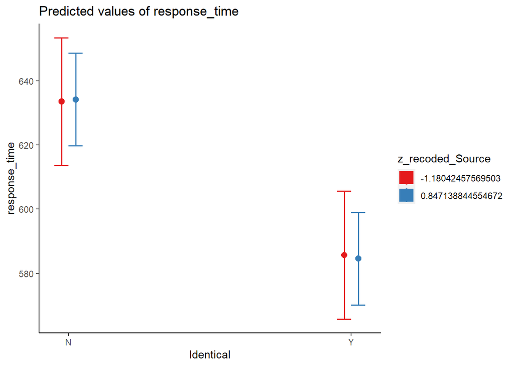

```r
#PP.source.lme <- lmerTest::lmer(response_time ~
#                    Identical*z_recoded_Source +                # Fixed effect
#                    (1 | Subject) +   # By-subject random intercept
#                    (1 | Picture1) +   # By-item random intercept
#                    (1 | PSA_ID) +    # By-lab random intercept
#                    (1 | Language),    # By-lab random intercept
#                    data = PP_lme_data,
                    #method = 'KR',               # Calculate p values using Kenward-Roger method
#                    control = lmerControl(optCtrl = list(maxfun = 1e6)) # Increase maximum number of iterations to facilitate model convergence
#                    )

# Plot interaction

sjPlot::plot_model(PP.z_source.slopes.cor.lme,
                   type = "pred",
                   terms = c('Identical', 'z_recoded_Source'),
                   ci.lvl = .95) +
#  geom_point() +
  guides(color=guide_legend(override.aes = list(size = 6))) +
  theme(panel.grid.major = element_blank(),
        panel.grid.minor = element_blank(),
        panel.background = element_blank(),
        axis.line = element_line(colour = "black"))
```

We learned the two facts from the analyses on the interactions of imagery scores and the potential variables: languages, datasets/teams, and data sources. *Firstly* we could exclude the sites and the data sources as the confounding factor altered the imagery scores. *On the other hand*, the interaction of orientation setting and languages supported the prediction model for a particular language rather than the prediction model for many languages.

### Regression model to predict orientation effect.

“In the second step, the imagery scores and languages will be the predictor in the regression model that uses the match advantage as the dependent variable. This regression model will be the prediction model for the match advantage of object orientation in future studies.”

The above analysis addresses the some languages showed larger imagery scores than the others. The data sources did not alter the imagery scores but alter the orientation effect. We will build the regression models to predict the orientation effect for the specific languages by the data source.

For each data source, we at first integrated the data of sentence-picture verification and picture-picture verification. Because the random intercept of items is zero, we computed the orientation effects and the imagery scores by participant.

```r
## I will merge the SP_V and PP data by participants' mean response times
model_site_data <- (SP_V_tidy %>% left_join(outliers_table, by=c("PSA_ID" = "LAB", "subject_nr" = "subject_nr")) %>%
  filter(Outlier == FALSE & Source == "site") %>%
  mutate(Subject = paste0(Source,"_",PSA_ID,"_",subject_nr)) %>%
  group_by(Language, Subject, Match) %>%
  summarise(subject_M = median(response_time)) %>%
#  group_by(Language, Match) %>%
#  summarise(N = n(), med_RT = median(subject_M), mean_ACC =   mean(subject_ACC)) %>%
  pivot_wider(names_from = Match, values_from = c(subject_M)) %>%
  mutate(Effect = (N - Y) )) %>%
left_join(
(PP_aov_data %>%
  select(-subject_ACC) %>%
  pivot_wider(names_from = Identical, values_from = subject_M) %>%
  mutate(Imagery = (N - Y))),
by = c("Language","Subject")
)


model_osweb_data <- (SP_V_tidy %>% left_join(outliers_table, by=c("PSA_ID" = "LAB", "subject_nr" = "subject_nr")) %>%
  filter(Outlier == FALSE & Source == "osweb") %>%
  mutate(Subject = paste0(Source,"_",PSA_ID,"_",subject_nr)) %>%
  group_by(Language, Subject, Match) %>%
  summarise(subject_M = median(response_time)) %>%
#  group_by(Language, Match) %>%
#  summarise(N = n(), med_RT = median(subject_M), mean_ACC =   mean(subject_ACC)) %>%
  pivot_wider(names_from = Match, values_from = c(subject_M)) %>%
  mutate(Effect = (N - Y) )) %>%
left_join(
(PP_aov_data %>%
  select(-subject_ACC) %>%
  pivot_wider(names_from = Identical, values_from = subject_M) %>%
  mutate(Imagery = (N - Y))),
by = c("Language","Subject")
)
```

- Prediction models for site data

We plotted the regression lines of orientation effect and imagery scores by each language respectively. There was no a general pattern appeared across the languages.

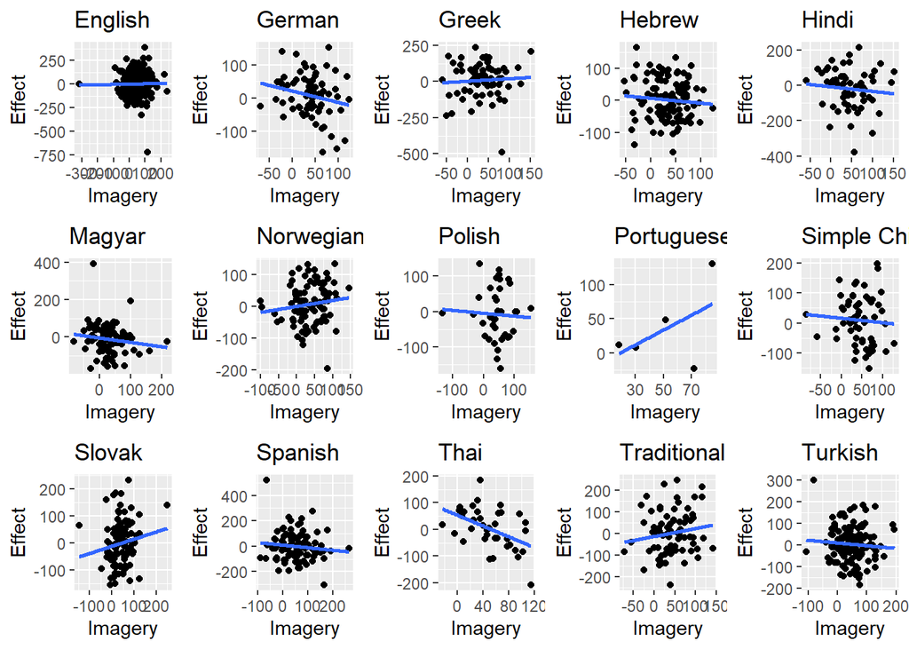

```r
lang_sets <- unique(model_site_data$Language)
site_plots <- list()
for(lang in lang_sets){
  site_plots[[lang]] <-  ggplot(subset(model_site_data, Language == lang), aes(Imagery, Effect)) +
    geom_point() +
    geom_smooth(method = "lm", se = FALSE) +
    labs(title=lang)
}

cowplot::plot_grid(plotlist = site_plots, ncol = 5)
```

To verify both the languages and imagery scores are the sufficient predictors for the orientation effects, we compared the fitness of regression models of only language and both predictors. The comparison indicated no difference between the models.

```r
site_lang_model1 <- lm(Effect ~ Language*Imagery, data=model_site_data)
site_lang_model0 <- lm(Effect ~ Language, data=site_lang_model1$model)
anova(site_lang_model0, site_lang_model1)
```

```
## Analysis of Variance Table
##
## Model 1: Effect ~ Language
## Model 2: Effect ~ Language * Imagery
##   Res.Df      RSS Df Sum of Sq     F Pr(>F)
## 1   1509 11493785
## 2   1494 11344460 15    149325 1.311 0.1869
```

```r
summary(site_lang_model0)
```

```
##
## Call:
## lm(formula = Effect ~ Language, data = site_lang_model1$model)
##
## Residuals:
##     Min      1Q  Median      3Q     Max
## -724.04  -52.04   -0.04   48.94  520.65
##
## Coefficients:
##                             Estimate Std. Error t value Pr(>|t|)
## (Intercept)                   3.0413     4.0171   0.757   0.4491
## LanguageGerman                4.9114    10.9118   0.450   0.6527
## LanguageGreek                 6.6025    10.9762   0.602   0.5476
## LanguageHebrew               -1.6385     9.3093  -0.176   0.8603
## LanguageHindi               -21.9810    12.1434  -1.810   0.0705 .
## LanguageMagyar              -14.4640     9.7294  -1.487   0.1373
## LanguageNorwegian             4.0081     9.9919   0.401   0.6884
## LanguagePolish              -11.0278    14.8996  -0.740   0.4593
## LanguagePortuguese           32.0587    39.2365   0.817   0.4140
## LanguageSimple Chinese        6.8994    12.0514   0.572   0.5671
## LanguageSlovak               -3.8617     9.4914  -0.407   0.6842
## LanguageSpanish              -4.1939     9.8140  -0.427   0.6692
## LanguageThai                 -0.2981    14.8996  -0.020   0.9840
## LanguageTraditional Chinese  -0.7721    10.6672  -0.072   0.9423
## LanguageTurkish               2.2105     8.4696   0.261   0.7941
## ---
## Signif. codes:  0 '***' 0.001 '**' 0.01 '*' 0.05 '.' 0.1 ' ' 1
##
## Residual standard error: 87.27 on 1509 degrees of freedom
## Multiple R-squared:  0.005937,   Adjusted R-squared:  -0.003285
## F-statistic: 0.6438 on 14 and 1509 DF,  p-value: 0.8296
```

- Prediction models for osweb data

We plotted the regression lines of orientation effect and imagery scores by each language respectively. There was no a general pattern appeared across the languages.

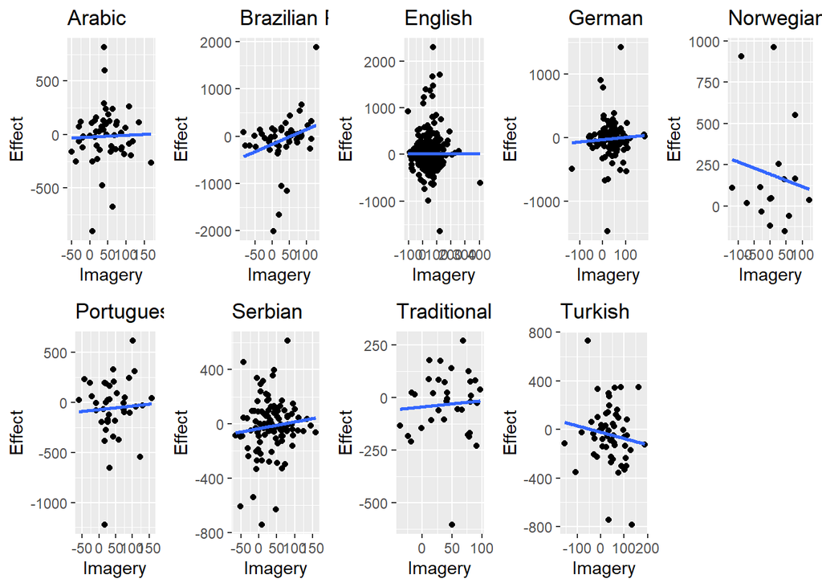

```r
lang_sets <- unique(model_osweb_data$Language)
osweb_plots <- list()
for(lang in lang_sets){
  osweb_plots[[lang]] <-  ggplot(subset(model_osweb_data, Language == lang), aes(Imagery, Effect)) +
    geom_point() +
    geom_smooth(method = "lm", se = FALSE) +
    labs(title=lang)
}

cowplot::plot_grid(plotlist = osweb_plots, ncol = 5)
```

To verify both the languages and imagery scores are the sufficient predictors for the orientation effects, we compared the fitness of regression models of only language and both predictors. The comparison indicated the two predictors better fitted the data.

The regression model indicated the significant coefficients for the Brazilian Portuguese. The result was consistent with the positive correlation of imagery scores and orientation effect for the Brazilian Portuguese.

```r
#osweb_lang_model <- lm(Effect ~ Language*Imagery, data=model_osweb_data)
#summary(osweb_lang_model)
model_osweb_data$Language <- if_else(model_osweb_data$Language=="English","0English",model_osweb_data$Language)

osweb_lang_model1 <- lm(Effect ~ Language*Imagery, data=model_osweb_data)
osweb_lang_model0 <- lm(Effect ~ Language, data=osweb_lang_model1$model)
anova(osweb_lang_model0, osweb_lang_model1)
```

```
## Analysis of Variance Table
##
## Model 1: Effect ~ Language
## Model 2: Effect ~ Language * Imagery
##   Res.Df      RSS Df Sum of Sq      F Pr(>F)
## 1   1088 89484022
## 2   1079 88026796  9   1457226 1.9847 0.0379 *
## ---
## Signif. codes:  0 '***' 0.001 '**' 0.01 '*' 0.05 '.' 0.1 ' ' 1
```

```r
BP_model <- lm(Effect ~ Imagery, data=subset(model_osweb_data, Language == "Brazilian Portuguese"))
summary(BP_model)
```

```
##
## Call:
## lm(formula = Effect ~ Imagery, data = subset(model_osweb_data,
##     Language == "Brazilian Portuguese"))
##
## Residuals:
##      Min       1Q   Median       3Q      Max
## -1849.94  -107.45    63.52   217.43  1642.71
##
## Coefficients:
##             Estimate Std. Error t value Pr(>|t|)
## (Intercept) -167.791     89.526  -1.874   0.0671 .
## Imagery        3.162      1.494   2.116   0.0397 *
## ---
## Signif. codes:  0 '***' 0.001 '**' 0.01 '*' 0.05 '.' 0.1 ' ' 1
##
## Residual standard error: 530.9 on 47 degrees of freedom
## Multiple R-squared:  0.08696,    Adjusted R-squared:  0.06754
## F-statistic: 4.477 on 1 and 47 DF,  p-value: 0.03969
```

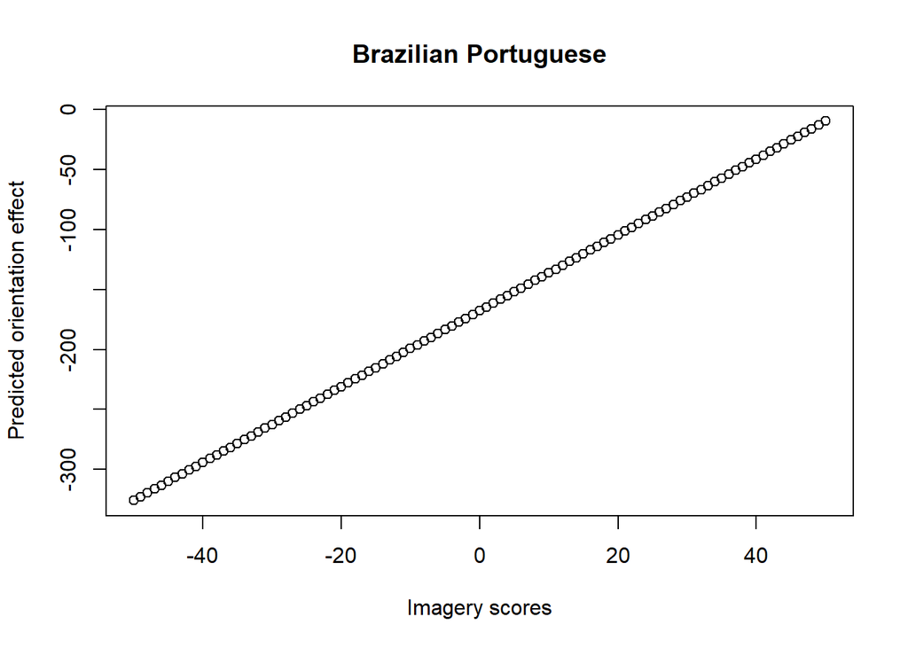

```r
plot(x = -50:50,
y = predict(BP_model, data.frame(Imagery = -50:50)),
ylab = "Predicted orientation effect",
xlab = "Imagery scores",
main = "Brazilian Portuguese",
type = "b")
```